# Black Thrive Shared Measurement System Methodology and Results

November 2021

[figure not shown]

# Overview

This document provides a description of the procedures undertaken to produce the first versions of Black Thrive’s new Shared Measurement System dashboards for Birmingham, Haringey, and Lambeth.

# R packages used

```r
library(tidyverse)
library(kableExtra) # for tables
library(leaflet) # for mapping
library(mapview) # for saving maps
library(gmodels) # for CrossTable
library(epitools) # for riskratio
library(forcats) # for factor reduction
```

# Data

The aim of this analysis was to produce new dashboards for Birmingham, Haringey and Lambeth, using the same set of indicators implemented in the previous iteration of the Lambeth dashboard. It has not yet been possible to acquire data for Birmingham and Haringey relating to the mental health indicators that are included in the Lambeth dashboard (Rate of Section 136 detentions, rate of episodes of physical restraint, and percentage of people with depression prior to starting Talking Therapies). It has also not been possible to acquire more recent data for these indicators for Lambeth. As our relationships with relevant public health authorities develop, we aim to update these dashboards with these and other health-related indicators. The table below lists the indicators included in this version of the dashboards, and the sources of their data.

| Indicator | Date | Source |
| --- | --- | --- |
| Good level of development | 2018-2019 academic year | [Early Years Foundation Stage Profile results](https://www.gov.uk/government/statistics/early-years-foundation-stage-profile-results-2018-to-2019) |
| Level 4+ GCSE Maths & English | 2019-2020 academic year | [Key Stage 4 performance](https://explore-education-statistics.service.gov.uk/find-statistics/key-stage-4-performance-revised#dataDownloads-1) |
| Children looked after by local authority | 2018-2019 financial year | [Children looked after in England including adoption](https://www.gov.uk/government/statistics/children-looked-after-in-england-including-adoption-2018-to-2019) |
| 16-64 year olds in employment | 12 months to March 2021 | [NOMIS Annual Population Survey](https://www.nomisweb.co.uk/datasets/apsnew) |
| Individuals subject to Stop and Search: Birmingham | 12 months to August 2021 | [Police API](https://data.police.uk) |
| Individuals subject to Stop and Search: Haringey & Lambeth | 12 months to August 2021 | [Metropolitan Police Stop and Search Dashboard Data](https://data.london.gov.uk/dataset/mps-stop-and-search-public-dashboard-data) |
| Homeless or at risk of becoming homeless | 2020-2021 financial year | [Live tables on homelessness; Detailed local authority level tables](https://www.gov.uk/government/statistical-data-sets/live-tables-on-homelessness#homelessness-summary-local-authority-level-tables) |
| Adult population | 2021 | [Annual Population Survey](https://www.nomisweb.co.uk/datasets/apsnew) |
| Child population: Birmingham | 2011 | [Census 2011](https://www.nomisweb.co.uk/census/2011/dc2101ew) |
| Child population: Haringey & Lambeth | 2019 | [Greater London Authority Ethnic group population projections](https://data.london.gov.uk/dataset/ethnic-group-population-projections) |
| Birmingham area coordinates |  | [MapIt by mySociety](https://mapit.mysociety.org/area/2514.html) |

Because it has not yet been possible to acquire more recent data for mental health outcomes, the mental health indicators for Lambeth were analysed based on crosstabulations derived from the data collected by Lambeth Public Health in a previous analysis. These indicators are presented in the table below.

```r
sources_df <- data.frame("Indicator" = c(
                                    "Individuals subject to detention per Section 136 of the Mental Health Act",
                                    "Individuals moderately to severely depressed prior to starting Talking Therapies",
                                    "Lambeth ward patients physically restrained"
                                    ),
                         "Date" = c(
                                    "2018/19",
                                    "2017/18",
                                    "2017/18"
                                    ),
                    "Source" = c(
                                 "EPJS, South London and Maudsley NHS Foundation Trust",
                                 "IAPTUS, South London and Maudsley NHS Foundation Trust",
                                 "DATIX, South London and Maudsley NHS Foundation Trust"
                                  )
)

sources_df %>% kbl() %>%
  kable_styling(full_width = F)
```

| Indicator | Date | Source |
| --- | --- | --- |
| Individuals subject to detention per Section 136 of the Mental Health Act | 2018/19 | EPJS, South London and Maudsley NHS Foundation Trust |
| Individuals moderately to severely depressed prior to starting Talking Therapies | 2017/18 | IAPTUS, South London and Maudsley NHS Foundation Trust |
| Lambeth ward patients physically restrained | 2017/18 | DATIX, South London and Maudsley NHS Foundation Trust |

Below, each indicator is briefly described, as well as how it was sourced and structured for the present analysis.

## Children achieving Good Level of Development

This indicator describes the number of children aged 4-5 years old who reach a “Good Level of Development” (GLD), defined as the achievement of expected level of development for Early Learning Goals and literacy and mathematics.

Data for this indicator were acquired from the *Early Years Foundation Stage Profile results: 2018-2019* produced by the Department for Education. This data provides the number of children reaching GLD and the total number of pupils according to the “ethnic” categories Asian, Black, Chinese, Mixed, and White. Subsets of this dataset were produced for Haringey and Birmingham by filtering the data based on the following criteria:

| Variable name | Value |
| --- | --- |
| la_name | Birmingham \| Haringey \| Lambeth |
| characteristic | Ethnicity |
| time_period | 201819 |

## Pupils achieving at least Level 4 in GCSE Maths and English

Data for the number of pupils achieving at least Level 4 in GCSE Maths and English were acquired from *Key Stage 4 performance 2019/20*, produced by the Department for Education. The variables of interest in this dataset were total number of pupils (*t_pupils*), total number achieving at least Level 4 (*t_l2basics_94*), and percentage achieving at least Level 4 (*pt_l2basics_94*). Subsets of this data were produced for Haringey and Birmingham by filtering the data according to the following criteria:

| Variable name | Value |
| --- | --- |
| la_name | Birmingham \| Haringey \| Lambeth |
| breakdown | Ethnic major |

## Children looked after by the local authority

This indicator describes the number of children looked after by the local authority. Data were acquired from *Children looked after in England including adoption: 2018 to 2019*, produced by the Department for Education. The following filter was applied to acquire data specific to each of Birmingham, Haringey. and Lambeth:

| Variable name | Value |
| --- | --- |
| geog_n | Birmingham \| Haringey \| Lambeth |

The variables of interest in this dataset were *CLA_Black* and *CLA_White*, which correspond to the number of children looked after by the local authority who are Black and White, respectively. In order to calculate the rate at which children were looked after by the local authority, these data were supplemented by child population statistics. For Haringey and Lambeth, child population estimates for 2019 were acquired via the Greater London Authority *Ethnic group population projections*, by filtering according to the following criteria:

| Variable name | Value |
| --- | --- |
| borough | Haringey \| Lambeth |
| age | 0-17 years old |
| ethnic_group | Black, White |

It was not possible to source population projections by ethnicity for Birmingham, so child populations statistics were drawn from the 2011 Census (*Census 2011: DC2101EW*). The data selected from this latter dataset were:

| Variable name | Value |
| --- | --- |
| Geography | Birmingham |
| Age | 0-17 years old |
| Ethnicity | Black, White |
| Sex | All |

## Employment

This indicator describes the number of 16-64 year olds in employment. The data for this indicator were acquired from the Office for National Statistics *Annual Population Survey* by querying the data on the NOMIS website. The query parameters used were:

| Variable name | Value |
| --- | --- |
| Geography | Birmingham \| Haringey \| Lambeth |
| Date | 12 months to March 2021 |
| Employment rate | aged 16-64 employment rate for all Black or Black British, aged 16-64 employment rate - White |

This data provides a *numerator*, which is the total number in employment, and a *denominator*, which is the population estimate for the ethnicity.

## Rate of Police Stop and Search

The procedure for Stop and Search data differed by local authority. For Birmingham, the Police API (published by the Single Online Home National Digital Team) was used to query Stop and Search data. To do this, it was first necessary to define the area of Birmingham using latitude and longitude coordinates. Coordinates of the city boundary were acquired from [MapIt by mySociety](https://mapit.mysociety.org/area/2514.html). This provided 3634 coordinate points that define the area of Birmingham, as below:

[figure not shown]

```r
# Get coordinates of Birmingham area
file <- jsonify::from_json("../data/birm_geo.json") # read json
coords <- as.data.frame(file[["coordinates"]][[1]]) # make dataframe
colnames(coords) <- c("long","lat") # name cols
coords_for_map <- coords # map wants long, lat
coords <- subset(coords, select = c("lat","long")) # swap columns for API (wants lat, long)
```

With these coordinates, the R package *httr* and a custom function were used to submit a http POST request to the Police API. The time period queried was the 12 months to the end of August 2021. The function used is provided in the code below. To summarise, it allows the user to specify a date range and a set of coordinates in which to search for Stop and Search data held on the Police API.

```r
# Acquire stop and search data in an area for a time period

# area_coords: area of interest. Must be a data frame with column names "lat" and "long"

# most_recent_month: numeric value specifying most recent month (e.g. 8 for August)

# most_recent_year (YYYY): numeric value specifying most recenet year (e.g. 2021)

# num_months_backwards: number of months backwards for which data are required.
# Default = 12. For example, if the most recent year of data is required,
# num_months_backwards would be 12

# If most_recent_month/year is not specified, function will query Police API for
# most recent update and use this as a start point

retrieve_area_data <- function(area_coords, most_recent_month = NULL, most_recent_year = NULL, num_months_backwards = 12){
  output <- data.frame() # initialise dataframe

  # make coordinate string for POST request
  coord_string <- c()
  for(i in 1:nrow(area_coords)){
    if(i == 1){
      coord_string <- paste(area_coords[i,"lat"],",",area_coords[i,"long"],sep="")
    }else{
    coord_string <- paste(coord_string,":",area_coords[i,"lat"],",",area_coords[i,"long"],sep="")
  }
  }
  # get most recent update if most_recent data not specified
  if(is.null(most_recent_month) || is.null(most_recent_year)){
    date <- httr::content(httr::GET("https://data.police.uk/api/crimes-street-dates"))[[1]][["date"]] # get most recent update
    most_recent_month <- as.numeric(substr(date,6,7))
    most_recent_year <- as.numeric(substr(date,1,4))
  }
  else{
    most_recent_month <- most_recent_month
    most_recent_year <- most_recent_year
  }

  # specify formatted date
  for(i in 1:num_months_backwards){
    if(i == 1){ # set values for first iteration
      month_num <- most_recent_month
      year <- most_recent_year
    }
    else{ # subsequent iterations
      month_num <- month_num - 1 # backwards a month each iteration
      if(month_num %% 12 == 0){ # if reach a new year, start months from 12 again
        month_num <- 12
        year <- year - 1 # backwards a year
      }
    }
    if(month_num < 10){ # paste 0 for months lower than 10
      month <- paste("0", month_num, sep = "")
    }
    else{
      month <- month_num
    }

  # build query
    date <- paste(year, "-", month, sep = "") # combine dates into format for API
    body <- list("poly" = coord_string,
                 "date" = date)
    post_request <- httr::POST("https://data.police.uk/api/stops-street?", body = body) # POST request
    df <- httr::content(post_request) # get content from response
    df_2 <- data.frame(t(sapply(df,c))) # convert to df
    output <- rbind(output, df_2) # add to dataframe
    print(paste("Working... ", i, " of ", num_months_backwards, " retrieved", sep = ""))
    print(date)
  }
  # unlist remaining listed columns. Not ideal solution; future versions could improve on this.
  output <- output %>%
    unnest_wider(., outcome_object, names_sep = ".") %>%
    unnest_wider(., location, names_sep = ".") %>%
    unnest_wider(., location.street, names_sep = ".")
  output <- as.matrix(output) # make matrix because write.csv runs into problems with list cols
  return(output)
}

# request made for the present data:
# data <- retrieve_area_data(coords, 8, 2021, 12)
```

It was not appropriate to use officer-defined ethnicity (variable name *officer_defined_ethnicity*) for the Birmingham dataset because for 66.21% of records this data was not reported (see the tables below). In contrast, self-defined ethnicity (*self_defined_ethnicity*) was reported for 91.03% of records, so this variable was used as the ethnicity variable in the present analysis. Ethnicity was aggregated into the broad categories of Black and White for consistency with the other indicators presented in this report.

### Officer-defined ethnicity count

| Officer-defined ethnicity | Count | Percentage |
| --- | --- | --- |
| Asian | 2373 | 28.00 |
| Black | 100 | 1.18 |
| Mixed | 4 | 0.05 |
| NULL | 5612 | 66.21 |
| Other | 200 | 2.36 |
| White | 187 | 2.21 |

### Self-defined ethnicity count

| Self-defined ethnicity | Count | Percentage |
| --- | --- | --- |
| Asian/Asian British - Any other Asian background | 367 | 4.33 |
| Asian/Asian British - Bangladeshi | 175 | 2.06 |
| Asian/Asian British - Chinese | 16 | 0.19 |
| Asian/Asian British - Indian | 312 | 3.68 |
| Asian/Asian British - Pakistani | 1949 | 22.99 |
| Black/African/Caribbean/Black British - African | 483 | 5.70 |
| Black/African/Caribbean/Black British - Any other Black/African/Caribbean background | 191 | 2.25 |
| Black/African/Caribbean/Black British - Caribbean | 587 | 6.93 |
| Mixed/Multiple ethnic groups - Any other Mixed/Multiple ethnic background | 157 | 1.85 |
| Mixed/Multiple ethnic groups - White and Asian | 91 | 1.07 |
| Mixed/Multiple ethnic groups - White and Black African | 67 | 0.79 |
| Mixed/Multiple ethnic groups - White and Black Caribbean | 292 | 3.45 |
| NULL | 760 | 8.97 |
| Other ethnic group - Any other ethnic group | 7 | 0.08 |
| Other ethnic group - Not stated | 501 | 5.91 |
| White - Any other White background | 339 | 4.00 |
| White - English/Welsh/Scottish/Northern Irish/British | 2139 | 25.24 |
| White - Irish | 43 | 0.51 |

```r
# stop and search
lambeth_data <- read.csv("../data/Stops_LDS_Extract_12MonthsToEnd_202108.csv")

lambeth_data <- subset(lambeth_data, Borough.of.Stop == "Lambeth") # subset to Lambeth

# officer-defined ethnicity
lambeth_appearance_freq_data <- lambeth_data %>%
  group_by(Ethnic.Appearance.Code) %>%
  summarise(
    n = n() # count frequencies
  ) %>%
  mutate(
    percentage = round(100 * (n / sum(n)), 2)
  )

lambeth_appearance_freq_data$Ethnic.Appearance.Code[1] <- "NULL"
lambeth_ethnicity_recorded <- 100 - sum(lambeth_appearance_freq_data$percentage[1:2])
```

### Haringey

#### Officer-defined ethnicity

| Officer-defined ethnicity | Count | Percentage |
| --- | --- | --- |
| NULL | 82 | 1.10 |
| 0 Unknown | 98 | 1.32 |
| 1 White - North European | 1435 | 19.30 |
| 2 White - South European | 1536 | 20.66 |
| 3 Black | 3502 | 47.10 |
| 4 Asian | 454 | 6.11 |
| 5 Chinese Japanese or South East Asian | 15 | 0.20 |
| 6 Middle Eastern | 313 | 4.21 |

#### Self-defined ethnicity

```r
# get codes
code_df <- data.frame(code = c("A1",
                               "A2",
                               "A3",
                               "A9",
                               "B1",
                               "B2",
                               "B9",
                               "M1",
                               "M2",
                               "M3",
                               "M9",
                               "O1",
                               "O9",
                               "W1",
                               "W2",
                               "W9",
                               "N1",
                               "N2",
                               "N3",
                               "N4"
                               ),
                      description = c("Indian",
                                      "Pakistani",
                                      "Bangladeshi",
                                      "Any other Asian background",
                                      "Black Caribbean",
                                      "Black African",
                                      "Any other Black background",
                                      "White and Black Caribbean",
                                      "White and Black African",
                                      "White and Asian",
                                      "Any other mixed background",
                                      "Chinese",
                                      "Any other ethnic group",
                                      "White British",
                                      "White Irish",
                                      "Any other White background",
                                      "The officer's presence is urgently required elsewhere",
                                      "The situation involves public disorder",
                                      "The person did not understand what is required",
                                      "The person declined to define their ethnicity"
                      )
)


data$ethnicity_code <- substr(data$Self.defined.Ethnicity.Code, 1,2)
for(i in 1:nrow(data)){
  for(j in 1:nrow(code_df)){
    if(data$ethnicity_code[i] == code_df$code[j]){
      data$self_defined_new[i] = code_df$description[j]
    }
  }
}
```

| Self-defined ethnicity | Count | Percentage |
| --- | --- | --- |
| NULL | 262 | 3.52 |
| Any other Black background | 967 | 13.01 |
| Any other ethnic group | 335 | 4.51 |
| Any other mixed background | 170 | 2.29 |
| Any other White background | 1255 | 16.88 |
| Bangladeshi | 50 | 0.67 |
| Black African | 991 | 13.33 |
| Black Caribbean | 472 | 6.35 |
| Chinese | 2 | 0.03 |
| Indian | 26 | 0.35 |
| Pakistani | 24 | 0.32 |
| The officer’s presence is urgently required elsewhere | 64 | 0.86 |
| The person declined to define their ethnicity | 1626 | 21.87 |
| The person did not understand what is required | 331 | 4.45 |
| The situation involves public disorder | 33 | 0.44 |
| White and Asian | 25 | 0.34 |
| White and Black African | 30 | 0.40 |
| White and Black Caribbean | 58 | 0.78 |
| White British | 642 | 8.63 |
| White Irish | 72 | 0.97 |

### Lambeth

#### Officer-defined ethnicity

| Officer-defined ethnicity | Count | Percentage |
| --- | --- | --- |
| NULL | 94 | 0.69 |
| 0 Unknown | 94 | 0.69 |
| 1 White - North European | 2786 | 20.51 |
| 2 White - South European | 1125 | 8.28 |
| 3 Black | 8415 | 61.95 |
| 4 Asian | 658 | 4.84 |
| 5 Chinese Japanese or South East Asian | 66 | 0.49 |
| 6 Middle Eastern | 346 | 2.55 |

#### Self-defined ethnicity

```r
# get codes
code_df <- data.frame(code = c("A1",
                               "A2",
                               "A3",
                               "A9",
                               "B1",
                               "B2",
                               "B9",
                               "M1",
                               "M2",
                               "M3",
                               "M9",
                               "O1",
                               "O9",
                               "W1",
                               "W2",
                               "W9",
                               "N1",
                               "N2",
                               "N3",
                               "N4"
                               ),
                      description = c("Indian",
                                      "Pakistani",
                                      "Bangladeshi",
                                      "Any other Asian background",
                                      "Black Caribbean",
                                      "Black African",
                                      "Any other Black background",
                                      "White and Black Caribbean",
                                      "White and Black African",
                                      "White and Asian",
                                      "Any other mixed background",
                                      "Chinese",
                                      "Any other ethnic group",
                                      "White British",
                                      "White Irish",
                                      "Any other White background",
                                      "The officer's presence is urgently required elsewhere",
                                      "The situation involves public disorder",
                                      "The person did not understand what is required",
                                      "The person declined to define their ethnicity"
                      )
)


lambeth_data$ethnicity_code <- substr(lambeth_data$Self.defined.Ethnicity.Code, 1,2)
for(i in 1:nrow(data)){
  for(j in 1:nrow(code_df)){
    if(lambeth_data$ethnicity_code[i] == code_df$code[j]){
      lambeth_data$self_defined_new[i] = code_df$description[j]
    }
  }
}
```

| Self-defined ethnicity | Count | Percentage |
| --- | --- | --- |
| NULL | 167 | 1.23 |
| Any other Black background | 1570 | 11.56 |
| Any other ethnic group | 116 | 0.85 |
| Any other mixed background | 124 | 0.91 |
| Any other White background | 661 | 4.87 |
| Bangladeshi | 38 | 0.28 |
| Black African | 613 | 4.51 |
| Black Caribbean | 644 | 4.74 |
| Chinese | 8 | 0.06 |
| Indian | 35 | 0.26 |
| Pakistani | 30 | 0.22 |
| The officer’s presence is urgently required elsewhere | 117 | 0.86 |
| The person declined to define their ethnicity | 1949 | 14.35 |
| The person did not understand what is required | 6509 | 47.92 |
| The situation involves public disorder | 37 | 0.27 |
| White and Asian | 9 | 0.07 |
| White and Black African | 21 | 0.15 |
| White and Black Caribbean | 69 | 0.51 |
| White British | 830 | 6.11 |
| White Irish | 37 | 0.27 |

All Stop and Search data were supplemented by population estimates data for Haringey and Birmingham from the 2021 *Annual Population Survey*.

## Households that are statutorily homeless or at risk of becoming homeless

This indicator describes the number of households that are owed prevention or relief duty, meaning that they are statutorily homeless or at risk of being so. The data were acquired from *Live tables on homelessness; Detailed authority level tables: Financial year 2020-21*, produced by the Department for Levelling Up, Housing, and Communities). The subset used for the current analysis is *Table A8: Ethnicity of main applicants assessed as owed a prevention or relief duty by local authority 2020-21 financial year*. From this table, data were selected corresponding to the Black and White populations of Haringey and Birmingham.

# Analysis and Results

Chi-square and Fisher exact tests were used to analyse the data. For each indicator, a crosstabulation was created containing the frequency of Black and White individuals for which the indicator outcome was true and the frequency for which it was false. This crosstabulation was then used to test whether the odds of the indicator outcome were significantly different for the Black population compared to the White population. This was done using the *CrossTable* function from the *gmodels* package in R. This function provides statistics for the Chi-square and Fisher exact tests as well an estimate of the odds ratio and its confidence interval.

A further step was taken to produce relative risk ratios for the public-facing dashboards. Relative risk ratios tend to be more intuitive to interpret for non-statisticians because the value presents relative increases or decreases in the *likelihood* of an outcome rather than in the *odds* of an outcome. Although odds ratios tend to approximate relative risk ratios when an outcome is uncommon (< 10%) in the comparator group (i.e., the White population), when the outcome is common (> 10%) in the comparator group odds ratios tend to exaggerate relative risk ratios (Davies, Crombie, and Tavakoli 1998). Relative risk ratios were calculated using the *riskratio* function from the *epitools* package in a custom function. This function restructures the data for each indicator in the format required for *riskratio* and then produces a relative risk ratio and its 95% confidence interval.

```r
rr_from_df <- function(df, name){
  # function takes dfs made earlier, transforms in matrices, and creates risk
  # ratios and associated confidence intervals
  # 'name' is the name of the indicator
  mat <- matrix(c(df[2,2],
                  df[2,1],
                  df[1,2],
                  df[1,1]), 2, 2)
  df_out <- data.frame("indicator" = name,
                     "rr" = riskratio(mat)[["measure"]][2,1],
                     "ci_low" = riskratio(mat)[["measure"]][2,2],
                     "ci_upp" = riskratio(mat)[["measure"]][2,3])
  return(df_out)
}
```

The results of this procedure for Birmingham, Haringey, and Lambeth are presented below. For each indicator, the code for preparing and analysing the data is provided, followed by a written report of the findings.

## Birmingham

### Summary

The analyses presented highlight four areas where the Black population of Birmingham experience worse outcomes than the White population. The odds of being employed for Black people are 0.48 times the odds for White people, meaning that Black people are 22.4% less likely than White people to be in employment. The odds of Black pupils achieving at least Level 4 in GCSE Maths and English are 0.76 times the odds for White pupils, meaning that Black pupils are 9.47% less likely than White pupils to achieve at least Level 4 in GCSE Maths and English. The odds of a Black individual being subject to Police Stop and Search are 2.65 times greater than the odds for a White individual, meaning that Black individuals are 163% (i.e., 2.63 times) more likely than White individuals to be stopped and searched by Police. The odds of Black households being statutorily homeless or at risk of becoming homeless are 3.22 times greater than the odds for a White households, meaning that White households are 220% (i.e., 3.2 times) more likely than White households to be homeless or at risk of becoming homeless. Finally, there appears to be no difference between Black and White children in the odds of being looked after by the local authority or of achieving a Good Level of Development at age 5.

The figures and tables below visualise these results both in terms of odds ratios and relative risk ratios.

#### Relative risk ratios

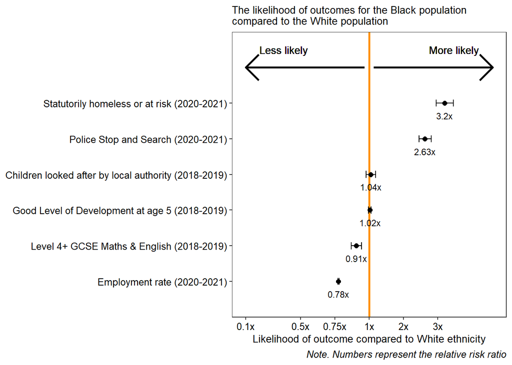

Relative risk ratios and confidence intervals corresponding to the above plot

| Indicator | Relative risk ratio | Lower confidence interval (95%) | Upper confidence interval (95%) |
| --- | --- | --- | --- |
| Statutorily homeless or at risk (2020-2021) | 3.20 | 2.95 | 3.46 |
| Police Stop and Search (2020-2021) | 2.63 | 2.45 | 2.81 |
| Children looked after by local authority (2018-2019) | 1.04 | 0.91 | 1.19 |
| Good Level of Development at age 5 (2018-2019) | 1.02 | 0.98 | 1.06 |
| Level 4+ GCSE Maths & English (2018-2019) | 0.91 | 0.87 | 0.94 |
| Employment rate (2020-2021) | 0.78 | 0.77 | 0.78 |

#### Odds ratios

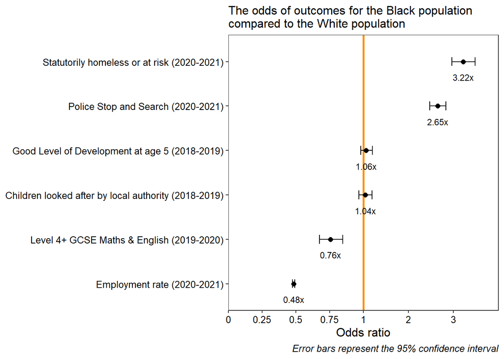

Odds ratios and confidence intervals corresponding to the above plot

| Indicator | Odds Ratio | Lower confidence interval (95%) | Upper confidence interval (95%) |
| --- | --- | --- | --- |
| Statutorily homeless or at risk (2020-2021) | 3.22 | 2.97 | 3.49 |
| Police Stop and Search (2020-2021) | 2.65 | 2.47 | 2.83 |
| Good Level of Development at age 5 (2018-2019) | 1.06 | 0.94 | 1.20 |
| Children looked after by local authority (2018-2019) | 1.04 | 0.90 | 1.19 |
| Level 4+ GCSE Maths & English (2019-2020) | 0.76 | 0.68 | 0.85 |
| Employment rate (2020-2021) | 0.48 | 0.48 | 0.49 |

Below, the results for each indicator are reported in detail.

### Children achieving Good Level of Development

```r
## good development
data <- read.csv("../data/birmingham_good_development_2018_2019_v2.csv")

total_data <- data %>%
  subset(gender == "Total") %>%
  subset(ethnicity != "Total")

row.names(total_data) <- total_data$ethnicity # set row names for indexing

# prepare data frame for crosstabs

black <- data.frame("black" = c("gld_number" = total_data["Black", "gld_number"], "not_gld_number" = total_data["Black", "number_of_pupils"] - total_data["Black", "gld_number"]))

white <- data.frame("white" = c("gld_number" = total_data["White", "gld_number"], "not_gld_number" = total_data["White", "number_of_pupils"] - total_data["White", "gld_number"]))

bw_mat <- as.matrix(cbind(black, white)) # combine black and white into one matrix
gld_df <- as.data.frame(bw_mat) # save df

rr <- rr_from_df(gld_df, "Good level of development at age 5 (2018-2019)") # get risk ratio
xtab <- CrossTable(bw_mat, fisher = T, chisq = T, expected = T) # save xtab
```

```
##
##
##    Cell Contents
## |-------------------------|
## |                       N |
## |              Expected N |
## | Chi-square contribution |
## |           N / Row Total |
## |           N / Col Total |
## |         N / Table Total |
## |-------------------------|
##
##
## Total Observations in Table:  7027
##
##
##                |     black |     white | Row Total |
## ---------------|-----------|-----------|-----------|
##     gld_number |      1168 |      3664 |      4832 |
##                |  1151.786 |  3680.214 |           |
##                |     0.228 |     0.071 |           |
##                |     0.242 |     0.758 |     0.688 |
##                |     0.697 |     0.685 |           |
##                |     0.166 |     0.521 |           |
## ---------------|-----------|-----------|-----------|
## not_gld_number |       507 |      1688 |      2195 |
##                |   523.214 |  1671.786 |           |
##                |     0.502 |     0.157 |           |
##                |     0.231 |     0.769 |     0.312 |
##                |     0.303 |     0.315 |           |
##                |     0.072 |     0.240 |           |
## ---------------|-----------|-----------|-----------|
##   Column Total |      1675 |      5352 |      7027 |
##                |     0.238 |     0.762 |           |
## ---------------|-----------|-----------|-----------|
##
##
## Statistics for All Table Factors
##
##
```

[output cut: 12 more lines]

```
##
## Alternative hypothesis: true odds ratio is not equal to 1
## p =  0.3338691
## 95% confidence interval:  0.94079 1.198239
##
## Alternative hypothesis: true odds ratio is less than 1
## p =  0.8436899
## 95% confidence interval:  0 1.175317
##
## Alternative hypothesis: true odds ratio is greater than 1
## p =  0.1712876
## 95% confidence interval:  0.9588271 Inf
##
##
##
```

The results indicate that there was no significant difference between Black children and White children in the odds of achieving a Good Level of Development at age 5, $\chi^{2}$(1, *N* = 7027) = 0.96, *p* = 0.327. The plot below shows that 69.73% of Black children and 68.46% of White children reached a Good Level of Development in 2018-2019.

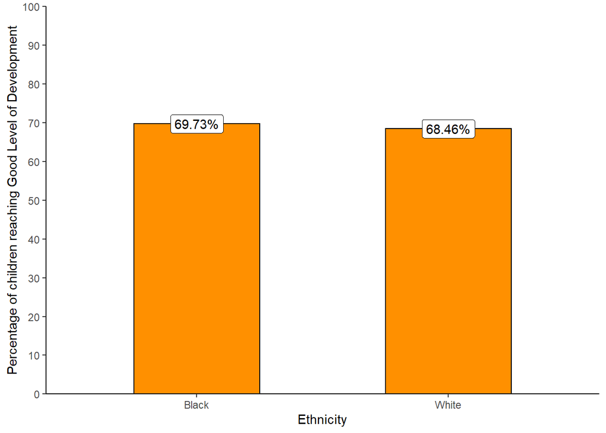

### Pupils achieving at least Level 4 in GCSE Maths and English

```r
data <- read.csv("../data/birmingham_4_plus_gcse_2019_2020_v2.csv")

# subset and rename
total_data <- data %>%
  subset(gender == "Total") %>%
  subset(ethnicity == "BLACK" | ethnicity == "WHITE") %>%
  rename(total_4_plus = t_l2basics_94,
         percent_4_plus = pt_l2basics_94)

# rename ethnicity levels and row names
total_data$ethnicity <- as.factor(total_data$ethnicity)
levels(total_data$ethnicity) <- c("Black","White")
row.names(total_data) <- total_data$ethnicity

total_data <- total_data[,-c(1)] # remove unnecessary column

# calculate number who didn't achieve level 4 plus
total_data <- total_data %>%
  mutate(
    not_gcse = t_pupils - total_4_plus
  )

# prepare data frame for xtab
black <- data.frame("black" = c("gcse" = total_data["Black", "total_4_plus"], "not_gcse" = total_data["Black", "not_gcse"]))
white <- data.frame("white" = c("gcse" = total_data["White", "total_4_plus"], "not_gcse" = total_data["White", "not_gcse"]))
bw_mat <- as.matrix(cbind(black, white))
gcse_df <- as.data.frame(bw_mat) # save df

# run stats
rr <- rr_from_df(gcse_df, "Level 4+ GCSE Maths & English (2018-2019)") # get risk ratio
xtab <- CrossTable(bw_mat, fisher = T, chisq = T, expected = T)
```

```
##
##
##    Cell Contents
## |-------------------------|
## |                       N |
## |              Expected N |
## | Chi-square contribution |
## |           N / Row Total |
## |           N / Col Total |
## |         N / Table Total |
## |-------------------------|
##
##
## Total Observations in Table:  6352
##
##
##              |     black |     white | Row Total |
## -------------|-----------|-----------|-----------|
##         gcse |      1154 |      3014 |      4168 |
##              |  1238.851 |  2929.149 |           |
##              |     5.812 |     2.458 |           |
##              |     0.277 |     0.723 |     0.656 |
##              |     0.611 |     0.675 |           |
##              |     0.182 |     0.474 |           |
## -------------|-----------|-----------|-----------|
##     not_gcse |       734 |      1450 |      2184 |
##              |   649.149 |  1534.851 |           |
##              |    11.091 |     4.691 |           |
##              |     0.336 |     0.664 |     0.344 |
##              |     0.389 |     0.325 |           |
##              |     0.116 |     0.228 |           |
## -------------|-----------|-----------|-----------|
## Column Total |      1888 |      4464 |      6352 |
##              |     0.297 |     0.703 |           |
## -------------|-----------|-----------|-----------|
##
##
## Statistics for All Table Factors
##
##
```

[output cut: 12 more lines]

```
##
## Alternative hypothesis: true odds ratio is not equal to 1
## p =  0.000001184091
## 95% confidence interval:  0.675428 0.8472768
##
## Alternative hypothesis: true odds ratio is less than 1
## p =  0.0000006140868
## 95% confidence interval:  0 0.8321658
##
## Alternative hypothesis: true odds ratio is greater than 1
## p =  0.9999995
## 95% confidence interval:  0.6876366 Inf
##
##
##
```

The results indicate that in the 2019-2020 academic year, there was a significant difference between Black pupils and White pupils in the odds of achieving at least a Level 4 in GCSE Maths and English, $\chi^{2}$(1, *N* = 6352) = 24.05, *p* < .001. The odds of a Black pupil achieving at least Level 4 in Maths and English were 0.76 times the odds for a White pupil (95% CI = 0.68 - 0.85). The relative risk ratio for Black pupils compared to White pupils was 0.91 (95% CI = 0.87 - 0.94), indicating that Black pupils were 9.47% less likely than White pupils to achieve at least Level 4 in GCSE Maths and English. The plot below shows that 61.12% of Black pupils achieved at least Level 4 in English and Maths, compared to 67.52% of White pupils.

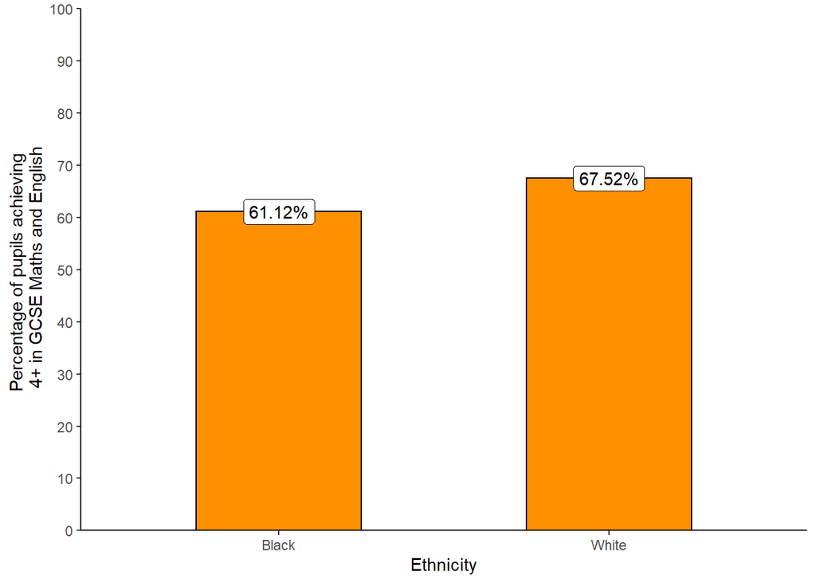

### Children looked after by the local authority

```r
# children looked after
data <- read.csv("../data/birmingham_cla_2018_2019_v2.csv")

# prepare data for analysis
total_data <- data %>%
  subset(ethnicity != "Total") %>%
  mutate(
    not_cla = pop - cla,
    percentage = as.numeric(percentage)
  )

total_data <- total_data[1:nrow(total_data) - 1,] # drop unknown
row.names(total_data) <- total_data$ethnicity

# prepare xtab
black <- data.frame("black" = c("cla" = total_data["Black", "cla"], "not_cla" = total_data["Black", "not_cla"]))
white <- data.frame("white" = c("cla" = total_data["White", "cla"], "not_cla" = total_data["White", "not_cla"]))
bw_mat <- as.matrix(cbind(black, white))
cla_df <- as.data.frame(bw_mat) # save df

# run analysis
rr <- rr_from_df(cla_df, "Children looked after by local authority (2018-2019)") # risk ratio
xtab <- CrossTable(bw_mat, fisher = T, chisq = T, expected = T)
```

```
##
##
##    Cell Contents
## |-------------------------|
## |                       N |
## |              Expected N |
## | Chi-square contribution |
## |           N / Row Total |
## |           N / Col Total |
## |         N / Table Total |
## |-------------------------|
##
##
## Total Observations in Table:  144468
##
##
##              |     black |     white | Row Total |
## -------------|-----------|-----------|-----------|
##          cla |       264 |       981 |      1245 |
##              |   256.156 |   988.844 |           |
##              |     0.240 |     0.062 |           |
##              |     0.212 |     0.788 |     0.009 |
##              |     0.009 |     0.009 |           |
##              |     0.002 |     0.007 |           |
## -------------|-----------|-----------|-----------|
##      not_cla |     29460 |    113763 |    143223 |
##              | 29467.844 | 113755.156 |           |
##              |     0.002 |     0.001 |           |
##              |     0.206 |     0.794 |     0.991 |
##              |     0.991 |     0.991 |           |
##              |     0.204 |     0.787 |           |
## -------------|-----------|-----------|-----------|
## Column Total |     29724 |    114744 |    144468 |
##              |     0.206 |     0.794 |           |
## -------------|-----------|-----------|-----------|
##
##
## Statistics for All Table Factors
##
##
```

[output cut: 12 more lines]

```
##
## Alternative hypothesis: true odds ratio is not equal to 1
## p =  0.5733443
## 95% confidence interval:  0.9031517 1.192428
##
## Alternative hypothesis: true odds ratio is less than 1
## p =  0.7230483
## 95% confidence interval:  0 1.167166
##
## Alternative hypothesis: true odds ratio is greater than 1
## p =  0.3008236
## 95% confidence interval:  0.9236985 Inf
##
##
##
```

The results indicate that, in the 2018-2019 financial year, there was no significant relationship between child ethnicity and the odds of being looked after the local authority, $\chi^{2}$(1, *N* = 144468) = 0.31, *p* = 0.581. The plot below shows that 0.89% of Black children and 0.85% of White children were looked after by the local authority in the 2018-2019 financial year.

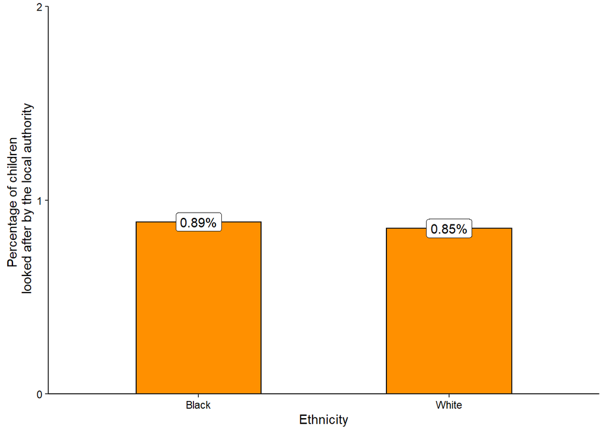

### Employment

```r
# employment
data <- read.csv("../data/birmingham_employment_rate_2020_2021_v2.csv")

# subset and organise data
total_data <- data %>%
  subset(gender == "all") %>%
  mutate(
    percentage = as.numeric(percentage),
    numerator = as.numeric(numerator),
    denominator = as.numeric(denominator),
    not_in_employment = denominator - numerator,
  )

row.names(total_data) <- total_data$ethnicity

# prepare xtab
black <- data.frame("black" = c("employed" = total_data["black", "numerator"], "not_employed" = total_data["black", "not_in_employment"]))
white <- data.frame("white" = c("employed" = total_data["white", "numerator"], "not_employed" = total_data["white", "not_in_employment"]))
bw_mat <- as.matrix(cbind(black, white))

employment_df <- as.data.frame(bw_mat) # save df

rr <- rr_from_df(employment_df, "Employment rate (2020-2021)") # risk ratio

# run analysis
xtab <- CrossTable(bw_mat, fisher = T, chisq = T, expected = T)
```

```
##
##
##    Cell Contents
## |-------------------------|
## |                       N |
## |              Expected N |
## | Chi-square contribution |
## |           N / Row Total |
## |           N / Col Total |
## |         N / Table Total |
## |-------------------------|
##
##
## Total Observations in Table:  491600
##
##
##              |     black |     white | Row Total |
## -------------|-----------|-----------|-----------|
##     employed |     51200 |    293200 |    344400 |
##              | 63261.432 | 281138.568 |           |
##              |  2299.634 |   517.461 |           |
##              |     0.149 |     0.851 |     0.701 |
##              |     0.567 |     0.731 |           |
##              |     0.104 |     0.596 |           |
## -------------|-----------|-----------|-----------|
## not_employed |     39100 |    108100 |    147200 |
##              | 27038.568 | 120161.432 |           |
##              |  5380.394 |  1210.689 |           |
##              |     0.266 |     0.734 |     0.299 |
##              |     0.433 |     0.269 |           |
##              |     0.080 |     0.220 |           |
## -------------|-----------|-----------|-----------|
## Column Total |     90300 |    401300 |    491600 |
##              |     0.184 |     0.816 |           |
## -------------|-----------|-----------|-----------|
##
##
## Statistics for All Table Factors
##
##
```

[output cut: 12 more lines]

```
##
## Alternative hypothesis: true odds ratio is not equal to 1
## p =  0
## 95% confidence interval:  0.4756259 0.4900722
##
## Alternative hypothesis: true odds ratio is less than 1
## p =  0
## 95% confidence interval:  0 0.488874
##
## Alternative hypothesis: true odds ratio is greater than 1
## p =  1
## 95% confidence interval:  0.4767621 Inf
##
##
##
```

```r
#chisq.test(bw_mat) double check result with chisq.test function
```

The results indicate that in the 12 months to March 2021, there was a significant difference between Black and White 16-64 year olds in the odds of being employed, $\chi^{2}$(1, *N* = 491600) = 9408.18, *p* < .001. The odds of Black 16-64 year olds being employed were 0.48 times the odds of White 16-64 year olds being employed (95% CI = 0.48 - 0.49). The relative risk ratio for Black individuals compared to White individuals was 0.78 (95% CI = 0.77 - 0.78), indicating that Black 16-64 year olds were 22.4% less likely than White 16-64 year olds to be in employment. The plot below shows that 56.7% of Black 16-64 year olds were employed in the 12 months to March 2021, compared to 73.06% of White 16-64 year olds.

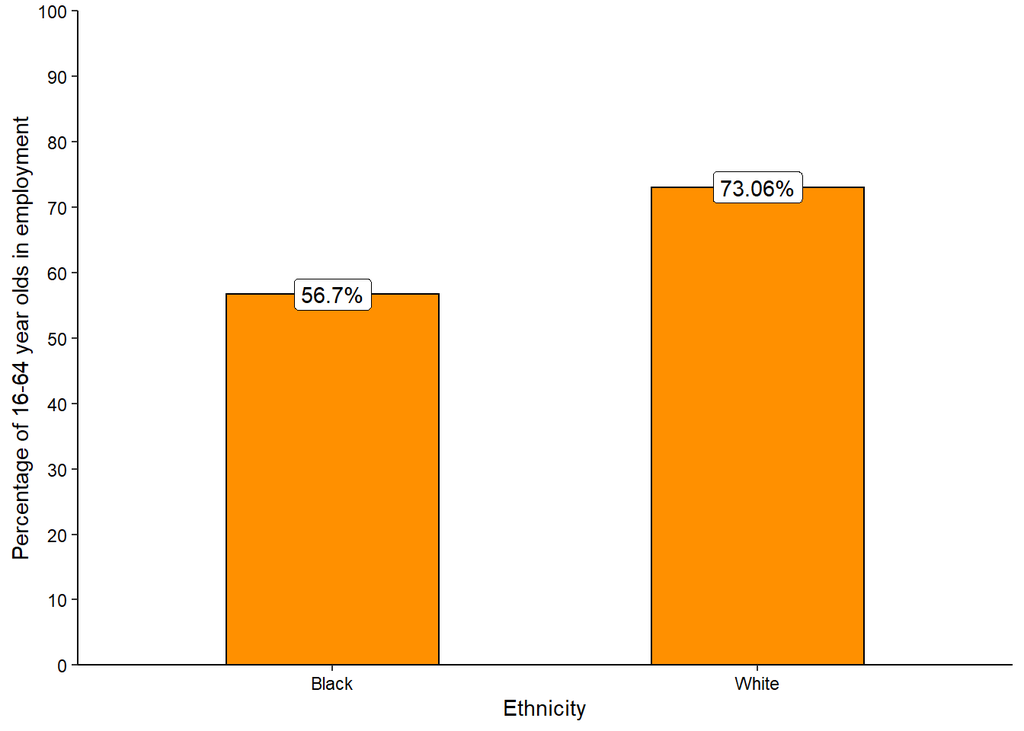

### Rate of Police Stop and Search

```r
# stop and search
data <- read.csv("../data/birmingham_stop_search_2020_09_2021_08.csv")

data$self_defined_ethnicity <- as.factor(data$self_defined_ethnicity)

# subset to just Black and White
data <- subset(data,
               self_defined_ethnicity == "Black/African/Caribbean/Black British - African" |
                 self_defined_ethnicity == "Black/African/Caribbean/Black British - Any other Black/African/Caribbean background"|
                 self_defined_ethnicity == "Black/African/Caribbean/Black British - Caribbean"|
                 self_defined_ethnicity == "White - Any other White background" |
                 self_defined_ethnicity == "White - English/Welsh/Scottish/Northern Irish/British" |
                 self_defined_ethnicity == "White - Irish")

data$self_defined_ethnicity_2 <- fct_collapse(data$self_defined_ethnicity,
                                              Black = c("Black/African/Caribbean/Black British - African",
                                                        "Black/African/Caribbean/Black British - Any other Black/African/Caribbean background",
                                                        "Black/African/Caribbean/Black British - Caribbean"),
                                              White = c("White - Any other White background",
                                              "White - English/Welsh/Scottish/Northern Irish/British",
                                              "White - Irish")
)

# officer-defined ethnicity
self_defined_freq_data <- data %>%
  group_by(self_defined_ethnicity_2) %>%
  summarise(
    n = n() # count frequencies
  ) %>%
  rename(
    ethnicity = self_defined_ethnicity_2
  )


# add population estimates
# population estimates taken from APS apr2020-mar2021
# Asian population = sum of Indian and Pakistani/Bangladeshi pops
population_stats <- data.frame("ethnicity" = c("Black", "White"),
                               "pop" = c(97100, 509700))

self_defined_freq_data <- self_defined_freq_data %>%
  merge(., population_stats, by = "ethnicity") %>%
  mutate(
    percentage = 100 * (n/pop),
    not_ss = pop - n
    )

row.names(self_defined_freq_data) <- self_defined_freq_data$ethnicity


# prepare xtabs
black <- data.frame("Black" = c("ss" = self_defined_freq_data["Black", "n"], "not_ss" = self_defined_freq_data["Black", "not_ss"]))
white <- data.frame("White" = c("ss" = self_defined_freq_data["White", "n"], "not_ss" = self_defined_freq_data["White", "not_ss"]))
bw_mat <- as.matrix(cbind(black, white))

stop_search_df <- as.data.frame(bw_mat) # save df
rr <- rr_from_df(stop_search_df, "Police Stop and Search (2020-2021)") # risk ratio

# run analysis
xtab <- CrossTable(bw_mat, fisher = T, chisq = T, expected = T)
```

```
##
##
##    Cell Contents
## |-------------------------|
## |                       N |
## |              Expected N |
## | Chi-square contribution |
## |           N / Row Total |
## |           N / Col Total |
## |         N / Table Total |
## |-------------------------|
##
##
## Total Observations in Table:  606800
##
##
##              |     Black |     White | Row Total |
## -------------|-----------|-----------|-----------|
##           ss |      1261 |      2521 |      3782 |
##              |   605.195 |  3176.805 |           |
##              |   710.648 |   135.381 |           |
##              |     0.333 |     0.667 |     0.006 |
##              |     0.013 |     0.005 |           |
##              |     0.002 |     0.004 |           |
## -------------|-----------|-----------|-----------|
##       not_ss |     95839 |    507179 |    603018 |
##              | 96494.805 | 506523.195 |           |
##              |     4.457 |     0.849 |           |
##              |     0.159 |     0.841 |     0.994 |
##              |     0.987 |     0.995 |           |
##              |     0.158 |     0.836 |           |
## -------------|-----------|-----------|-----------|
## Column Total |     97100 |    509700 |    606800 |
##              |     0.160 |     0.840 |           |
## -------------|-----------|-----------|-----------|
##
##
## Statistics for All Table Factors
##
##
```

[output cut: 12 more lines]

```
##
## Alternative hypothesis: true odds ratio is not equal to 1
## p =  2.495238e-152
## 95% confidence interval:  2.471176 2.834373
##
## Alternative hypothesis: true odds ratio is less than 1
## p =  1
## 95% confidence interval:  0 2.803673
##
## Alternative hypothesis: true odds ratio is greater than 1
## p =  2.059214e-152
## 95% confidence interval:  2.498555 Inf
##
##
##
```

The results indicate that in the 12 months to August 2021, there was a significant difference between Black and White individuals in the odds of being stopped and searched by Police, $\chi^{2}$(1, *N* = 606800) = 851.34, *p* < .001. The odds of a Black individual being stopped and searched by police were 2.65 times the odds of a White individual being stopped and searched (95% CI = 2.47 - 2.83). The relative risk ratio for Black individuals compared to White individuals was 2.63 (95% CI = 2.45 - 2.81), indicating that Black individuals were 163% (i.e., 2.63 times) more likely than White individuals to be stopped and searched by Police. The plot below shows that 1.3% of Black individuals in Birmingham were subject to Police Stop and Search, compared to 0.49% of White individuals.

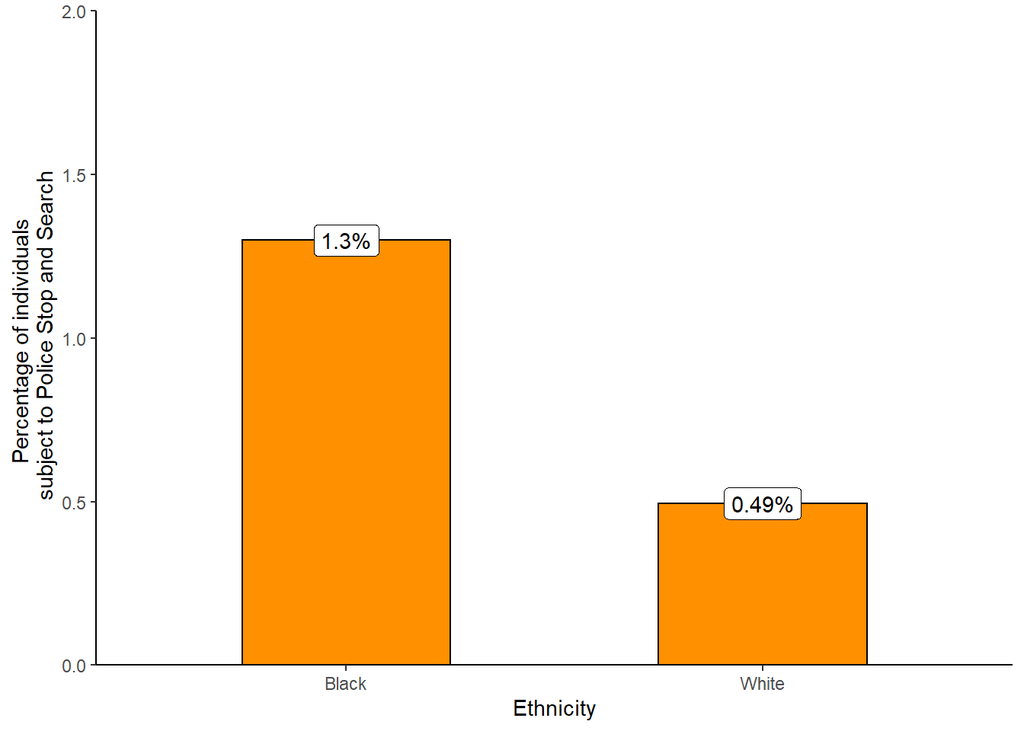

### Households that are statutorily homeless or at risk of becoming homeless

```r
# homelessness
data <- read.csv("../data/birmingham_stat_homeless_2020_2021_v2.csv")

total_data <- data %>%
  subset(ethnicity == "Asian" | ethnicity == "Black" | ethnicity == "Mixed/multiple" | ethnicity == "Other" | ethnicity == "White")

total_data <- total_data[,-c(4)]
total_data <- total_data[order(total_data$ethnicity),]
total_data$ethnicity <- as.factor(total_data$ethnicity)
total_data$number_homeless <- as.numeric(total_data$number_homeless)
row.names(total_data) <- total_data$ethnicity


# in homelessness dataset Chinese is included in Asian
# in population dataset it isn't. Need to account for this by taking chinese
# from asian category and adding them to other category
total_data["Asian","number_homeless"] <- total_data["Asian","number_homeless"] - 2
total_data["Other", "number_homeless"] <- total_data["Other", "number_homeless"] + 2

total_data <- total_data %>%
    mutate(
    percentage = 100*(number_homeless/population),
    number_not_homeless = population - number_homeless
    )

# prepare xtab
black <- data.frame("black" = c("homeless" = total_data["Black", "number_homeless"], "not_homeless" = total_data["Black", "number_not_homeless"]))
white <- data.frame("white" = c("homeless" = total_data["White", "number_homeless"], "not_homeless" = total_data["White", "number_not_homeless"]))
bw_mat <- as.matrix(cbind(black, white))

homeless_df <- as.data.frame(bw_mat) # save df
rr <- rr_from_df(homeless_df, "Statutorily homeless or at risk (2020-2021)") # risk ratio

# run analysis
xtab <- CrossTable(bw_mat, fisher = T, chisq = T, expected = T)
```

```
##
##
##    Cell Contents
## |-------------------------|
## |                       N |
## |              Expected N |
## | Chi-square contribution |
## |           N / Row Total |
## |           N / Col Total |
## |         N / Table Total |
## |-------------------------|
##
##
## Total Observations in Table:  606800
##
##
##              |     black |     white | Row Total |
## -------------|-----------|-----------|-----------|
##     homeless |       994 |      1633 |      2627 |
##              |   420.372 |  2206.628 |           |
##              |   782.757 |   149.119 |           |
##              |     0.378 |     0.622 |     0.004 |
##              |     0.010 |     0.003 |           |
##              |     0.002 |     0.003 |           |
## -------------|-----------|-----------|-----------|
## not_homeless |     96106 |    508067 |    604173 |
##              | 96679.628 | 507493.372 |           |
##              |     3.404 |     0.648 |           |
##              |     0.159 |     0.841 |     0.996 |
##              |     0.990 |     0.997 |           |
##              |     0.158 |     0.837 |           |
## -------------|-----------|-----------|-----------|
## Column Total |     97100 |    509700 |    606800 |
##              |     0.160 |     0.840 |           |
## -------------|-----------|-----------|-----------|
##
##
## Statistics for All Table Factors
##
##
```

[output cut: 12 more lines]

```
##
## Alternative hypothesis: true odds ratio is not equal to 1
## p =  3.910051e-161
## 95% confidence interval:  2.969872 3.485088
##
## Alternative hypothesis: true odds ratio is less than 1
## p =  1
## 95% confidence interval:  0 3.441255
##
## Alternative hypothesis: true odds ratio is greater than 1
## p =  3.023572e-161
## 95% confidence interval:  3.008277 Inf
##
##
##
```

The results indicate that in the 2020-2021 financial year, there was a significant difference in the odds of being homeless or at risk of being homeless between Black and White households, $\chi^{2}$(1, *N* = 606800) = 935.93, *p* < .001. The odds of a Black household being owed prevention or relief duty were 3.22 times the odds for a White household (95% CI = 2.97 - 3.49). The relative risk ratio for Black households compared to White households was 3.2 (95% CI = 2.95 - 3.46), indicating that Black households were 220% (i.e., 3.2 times) more likely than White households to be statutorily homeless or at risk of being so. The plot below shows that 1.02% of Black households in Birmingham were homeless or at risk of becoming homeless, compared to 0.32% of White households.

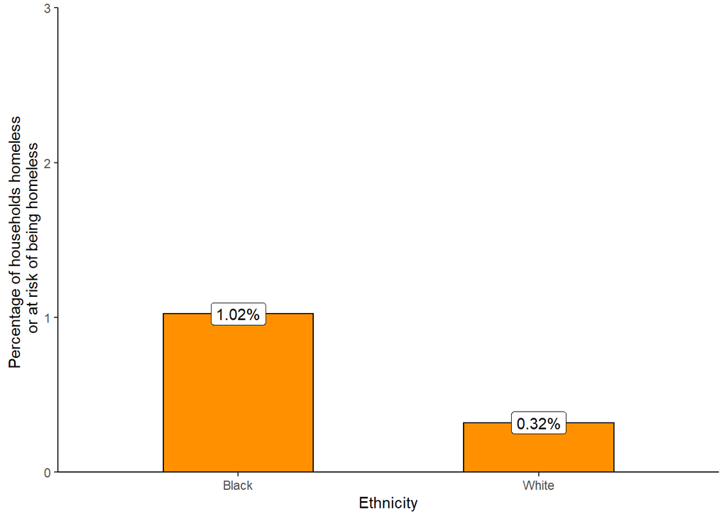

## Haringey

### Summary

The analyses presented for Haringey highlight five areas where the Black population experience worse outcomes than the White population. The odds of being employed for Black people are 0.52 times the odds for White people, meaning that Black people are 17.18% less likely than White people to be in employment. The odds of Black children achieving a Good Level of Development at age 5 are 0.69 times the odds for White children, meaning that Black pupils are 9.15% less likely than White children to reach a Good Level of Development. The odds of Black children being looked after by the local authority are 4.47 times the odds for White children, meaning that Black children are 341% (i.e., 4.41 times) more likely than White children to be looked after by the local authority. The odds of a Black individual being subject to Police Stop and Search are 7.08 times greater than the odds for a White individual, meaning that Black individuals are 559% (i.e., 6.59 times) more likely than White individuals to be stopped and searched by Police. The odds of Black households being statutorily homeless or at risk of becoming homeless are 7.94 times greater than the odds for a White households, meaning that White households are 676% (i.e., 7.76 times) more likely than White households to be homeless or at risk of becoming homeless. Finally, there appears to be no difference between Black and White pupils in the odds of achieving at least Level 4 in GCSE Maths and English.

The figures and tables below visualise these results both in terms of odds ratios and relative risk ratios.

#### Relative risk ratios

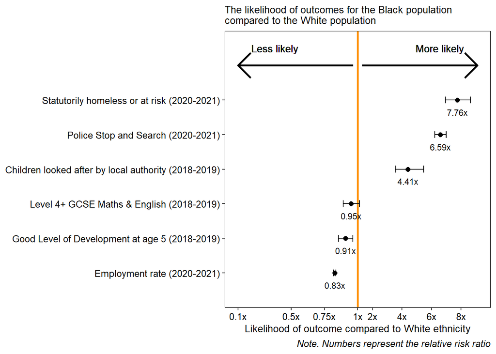

Relative risk ratios and confidence intervals corresponding to the above plot

| Indicator | Relative risk ratio | Lower confidence interval (95%) | Upper confidence interval (95%) |
| --- | --- | --- | --- |
| Statutorily homeless or at risk (2020-2021) | 7.76 | 6.96 | 8.66 |
| Police Stop and Search (2020-2021) | 6.59 | 6.22 | 6.99 |
| Children looked after by local authority (2018-2019) | 4.41 | 3.55 | 5.48 |
| Level 4+ GCSE Maths & English (2018-2019) | 0.95 | 0.89 | 1.01 |
| Good Level of Development at age 5 (2018-2019) | 0.91 | 0.86 | 0.96 |
| Employment rate (2020-2021) | 0.83 | 0.82 | 0.84 |

#### Odds ratios

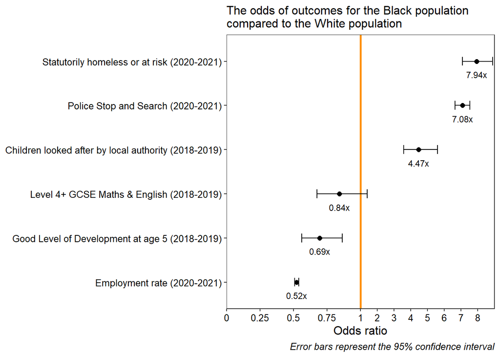

Odds ratios and confidence intervals corresponding to the above plot

| Indicator | Odds Ratio | Lower confidence interval (95%) | Upper confidence interval (95%) |
| --- | --- | --- | --- |
| Statutorily homeless or at risk (2020-2021) | 7.94 | 7.10 | 8.89 |
| Police Stop and Search (2020-2021) | 7.08 | 6.66 | 7.53 |
| Children looked after by local authority (2018-2019) | 4.47 | 3.57 | 5.61 |
| Level 4+ GCSE Maths & English (2018-2019) | 0.84 | 0.68 | 1.05 |
| Good Level of Development at age 5 (2018-2019) | 0.69 | 0.56 | 0.86 |
| Employment rate (2020-2021) | 0.52 | 0.51 | 0.54 |

Below, the results for each indicator are reported in detail.

### Children achieving Good Level of Development

```r
## good development
data <- read.csv("../data/haringey_good_development_2018_2019_v2.csv")

total_data <- data %>%
  subset(gender == "Total") %>%
  subset(characteristic_type != "Total")

row.names(total_data) <- total_data$characteristic_type # set row names for indexing

total_data <- total_data[,-c(1:3)] # get rid of unnecessary cols

# prepare data frame for crosstabs

black <- data.frame("black" = c("gld_number" = total_data["Black", "gld_number"], "not_gld_number" = total_data["Black", "number_of_pupils"] - total_data["Black", "gld_number"]))

white <- data.frame("white" = c("gld_number" = total_data["White", "gld_number"], "not_gld_number" = total_data["White", "number_of_pupils"] - total_data["White", "gld_number"]))

bw_mat <- as.matrix(cbind(black, white)) # combine black and white into one matrix
gld_df <- as.data.frame(bw_mat) # save df

rr <- rr_from_df(gld_df, "Good level of development at age 5 (2018-2019)") # risk ratio

xtab <- CrossTable(bw_mat, fisher = T, chisq = T, expected = T) # save xtab
```

```
##
##
##    Cell Contents
## |-------------------------|
## |                       N |
## |              Expected N |
## | Chi-square contribution |
## |           N / Row Total |
## |           N / Col Total |
## |         N / Table Total |
## |-------------------------|
##
##
## Total Observations in Table:  2103
##
##
##                |     black |     white | Row Total |
## ---------------|-----------|-----------|-----------|
##     gld_number |       425 |      1153 |      1578 |
##                |   455.466 |  1122.534 |           |
##                |     2.038 |     0.827 |           |
##                |     0.269 |     0.731 |     0.750 |
##                |     0.700 |     0.771 |           |
##                |     0.202 |     0.548 |           |
## ---------------|-----------|-----------|-----------|
## not_gld_number |       182 |       343 |       525 |
##                |   151.534 |   373.466 |           |
##                |     6.125 |     2.485 |           |
##                |     0.347 |     0.653 |     0.250 |
##                |     0.300 |     0.229 |           |
##                |     0.087 |     0.163 |           |
## ---------------|-----------|-----------|-----------|
##   Column Total |       607 |      1496 |      2103 |
##                |     0.289 |     0.711 |           |
## ---------------|-----------|-----------|-----------|
##
##
## Statistics for All Table Factors
##
##
```

[output cut: 12 more lines]

```
##
## Alternative hypothesis: true odds ratio is not equal to 1
## p =  0.0008428681
## 95% confidence interval:  0.5596396 0.8639332
##
## Alternative hypothesis: true odds ratio is less than 1
## p =  0.0004877179
## 95% confidence interval:  0 0.8347879
##
## Alternative hypothesis: true odds ratio is greater than 1
## p =  0.9996708
## 95% confidence interval:  0.5788231 Inf
##
##
##
```

The results indicate that in Haringey there was a significant difference between Black children and White children in the odds of achieving a Good Level of Development at age 5, $\chi^{2}$(1, *N* = 2103) = 11.48, *p* < .001. The odds of a Black child reaching a Good Level of Development were 0.69 times the odds for a White child (95% CI = 0.56 - 0.86). The relative risk ratio for Black children compared to White children was 0.91 (95% CI = 0.86 - 0.96), indicating that Black children were 9.15% less likely than White children to reach a Good Level of Development at age 5. The plot below shows that 70.02% of Black children and 77.07% of White children reached a Good Level of Development in 2018-2019.

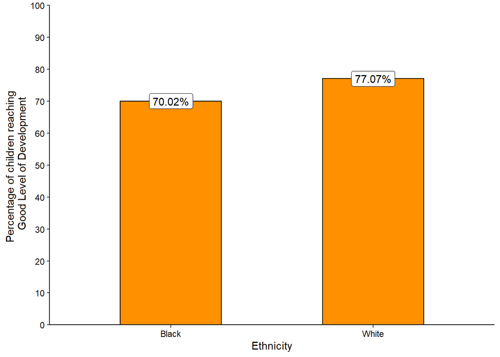

### Pupils achieving at least Level 4 in GCSE Maths and English

```r
data <- read.csv("../data/haringey_4_plus_gcse_english_maths_2019_2020_v2.csv")

# subset and rename
total_data <- data %>%
  subset(gender == "Total") %>%
  subset(ethnicity == "BLACK" | ethnicity == "WHITE") %>%
  rename(total_4_plus = t_l2basics_94,
         percent_4_plus = pt_l2basics_94)

# rename ethnicity levels and row names
total_data$ethnicity <- as.factor(total_data$ethnicity)
levels(total_data$ethnicity) <- c("Black","White")
row.names(total_data) <- total_data$ethnicity

total_data <- total_data[,-c(1)] # remove unnecessary column

# calculate number who didn't achieve level 4 plus
total_data <- total_data %>%
  mutate(
    not_gcse = total_pupils - total_4_plus
  )

# prepare data frame for xtab
black <- data.frame("black" = c("gcse" = total_data["Black", "total_4_plus"], "not_gcse" = total_data["Black", "not_gcse"]))
white <- data.frame("white" = c("gcse" = total_data["White", "total_4_plus"], "not_gcse" = total_data["White", "not_gcse"]))
bw_mat <- as.matrix(cbind(black, white))
gcse_df <- as.data.frame(bw_mat) # save df

rr <- rr_from_df(gcse_df, "Level 4+ GCSE Maths & English (2018-2019)") # risk ratio

# run stats
xtab <- CrossTable(bw_mat, fisher = T, chisq = T, expected = T)
```

```
##
##
##    Cell Contents
## |-------------------------|
## |                       N |
## |              Expected N |
## | Chi-square contribution |
## |           N / Row Total |
## |           N / Col Total |
## |         N / Table Total |
## |-------------------------|
##
##
## Total Observations in Table:  1753
##
##
##              |     black |     white | Row Total |
## -------------|-----------|-----------|-----------|
##         gcse |       425 |       823 |      1248 |
##              |   439.256 |   808.744 |           |
##              |     0.463 |     0.251 |           |
##              |     0.341 |     0.659 |     0.712 |
##              |     0.689 |     0.724 |           |
##              |     0.242 |     0.469 |           |
## -------------|-----------|-----------|-----------|
##     not_gcse |       192 |       313 |       505 |
##              |   177.744 |   327.256 |           |
##              |     1.143 |     0.621 |           |
##              |     0.380 |     0.620 |     0.288 |
##              |     0.311 |     0.276 |           |
##              |     0.110 |     0.179 |           |
## -------------|-----------|-----------|-----------|
## Column Total |       617 |      1136 |      1753 |
##              |     0.352 |     0.648 |           |
## -------------|-----------|-----------|-----------|
##
##
## Statistics for All Table Factors
##
##
```

[output cut: 12 more lines]

```
##
## Alternative hypothesis: true odds ratio is not equal to 1
## p =  0.1221563
## 95% confidence interval:  0.6758453 1.050048
##
## Alternative hypothesis: true odds ratio is less than 1
## p =  0.06471937
## 95% confidence interval:  0 1.014238
##
## Alternative hypothesis: true odds ratio is greater than 1
## p =  0.9480283
## 95% confidence interval:  0.6993654 Inf
##
##
##
```

The results indicate that in the 2019-2020 academic year, there was no statistically significant difference between Black pupils and White pupils in the odds of achieving at least a Level 4 in GCSE Maths and English, $\chi^{2}$(1, *N* = 1753) = 2.48, *p* = 0.115. The plot below shows that 68.9% of Black pupils achieved at least Level 4 in English and Maths, compared to 72.4% of White pupils.

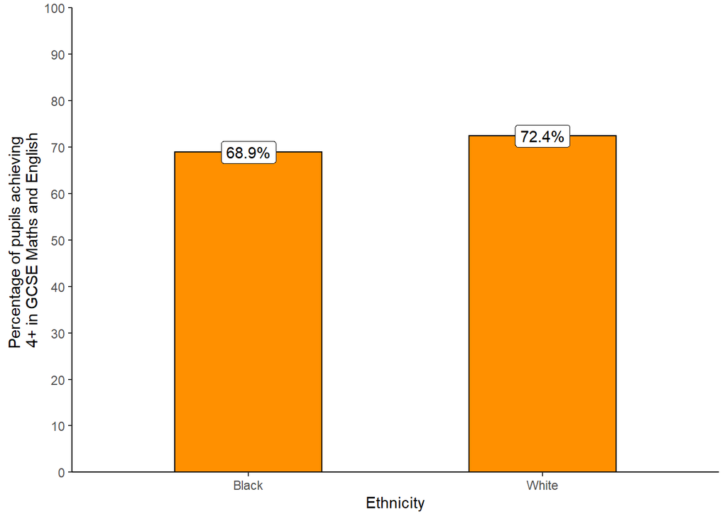

### Children looked after by the local authority

```r
# children looked after
data <- read.csv("../data/haringey_children_looked_after_2018_2019_v3.csv")

# prepare data for analysis
total_data <- data %>%
  subset(ethnicity == "Black" | ethnicity == "White") %>%
  mutate(
    not_cla = pop - cla,
    percentage = as.numeric(percentage)
  )

row.names(total_data) <- total_data$ethnicity

# prepare xtab
black <- data.frame("black" = c("cla" = total_data["Black", "cla"], "not_cla" = total_data["Black", "not_cla"]))
white <- data.frame("white" = c("cla" = total_data["White", "cla"], "not_cla" = total_data["White", "not_cla"]))
bw_mat <- as.matrix(cbind(black, white))
cla_df <- as.data.frame(bw_mat) # save df

rr <- rr_from_df(cla_df, "Children looked after by local authority (2018-2019)") # risk ratio

# run analysis
xtab <- CrossTable(bw_mat, fisher = T, chisq = T, expected = T)
```

```
##
##
##    Cell Contents
## |-------------------------|
## |                       N |
## |              Expected N |
## | Chi-square contribution |
## |           N / Row Total |
## |           N / Col Total |
## |         N / Table Total |
## |-------------------------|
##
##
## Total Observations in Table:  45020
##
##
##              |     black |     white | Row Total |
## -------------|-----------|-----------|-----------|
##          cla |       231 |       124 |       355 |
##              |   105.483 |   249.517 |           |
##              |   149.357 |    63.140 |           |
##              |     0.651 |     0.349 |     0.008 |
##              |     0.017 |     0.004 |           |
##              |     0.005 |     0.003 |           |
## -------------|-----------|-----------|-----------|
##      not_cla |     13146 |     31519 |     44665 |
##              | 13271.517 | 31393.483 |           |
##              |     1.187 |     0.502 |           |
##              |     0.294 |     0.706 |     0.992 |
##              |     0.983 |     0.996 |           |
##              |     0.292 |     0.700 |           |
## -------------|-----------|-----------|-----------|
## Column Total |     13377 |     31643 |     45020 |
##              |     0.297 |     0.703 |           |
## -------------|-----------|-----------|-----------|
##
##
## Statistics for All Table Factors
##
##
```

[output cut: 12 more lines]

```
##
## Alternative hypothesis: true odds ratio is not equal to 1
## p =  3.435684e-43
## 95% confidence interval:  3.571629 5.606582
##
## Alternative hypothesis: true odds ratio is less than 1
## p =  1
## 95% confidence interval:  0 5.408571
##
## Alternative hypothesis: true odds ratio is greater than 1
## p =  2.56156e-43
## 95% confidence interval:  3.697163 Inf
##
##
##
```

The results indicate that, in the 2018-2019 financial year, there was a significant relationship between child ethnicity and the odds of being looked after the local authority, $\chi^{2}$(1, *N* = 45020) = 214.19, *p* < .001. The odds of Black children being looked after by the local authority were 4.47 times the odds for White children (95% CI = 3.57 - 5.61). The relative risk ratio for Black children compared to White children was 4.41 (95% CI = 3.55 - 5.48), indicating that Black children were 341% (i.e., 4.41 times) more likely than White children to be looked after by the local authority. The plot below shows that 1.73% of Black children, compared to 0.39% of White children, were looked after by the local authority in the 2018-2019 financial year.

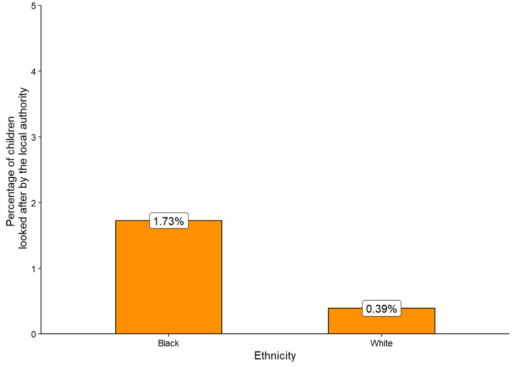

### Employment

```r
# employment
data <- read.csv("../data/haringey_employment_rate_2020_2021_v3.csv")

# subset and organise data
total_data <- data %>%
  subset(gender == "all") %>%
  subset(ethnicity == "black" | ethnicity == "white") %>%
  mutate(
    percentage = as.numeric(percentage) * 100,
    numerator = as.numeric(numerator),
    denominator = as.numeric(denominator),
    not_in_employment = denominator - numerator,
  )

row.names(total_data) <- total_data$ethnicity

# prepare xtab
black <- data.frame("black" = c("employed" = total_data["black", "numerator"], "not_employed" = total_data["black", "not_in_employment"]))
white <- data.frame("white" = c("employed" = total_data["white", "numerator"], "not_employed" = total_data["white", "not_in_employment"]))
bw_mat <- as.matrix(cbind(black, white))
employment_df <- as.data.frame(bw_mat) # save df

rr <- rr_from_df(employment_df, "Employment rate (2020-2021)") # risk ratio

# run analysis
xtab <- CrossTable(bw_mat, fisher = T, chisq = T, expected = T)
```

```
##
##
##    Cell Contents
## |-------------------------|
## |                       N |
## |              Expected N |
## | Chi-square contribution |
## |           N / Row Total |
## |           N / Col Total |
## |         N / Table Total |
## |-------------------------|
##
##
## Total Observations in Table:  169200
##
##
##              |     black |     white | Row Total |
## -------------|-----------|-----------|-----------|
##     employed |     14600 |    113200 |    127800 |
##              | 17221.277 | 110578.723 |           |
##              |   398.988 |    62.138 |           |
##              |     0.114 |     0.886 |     0.755 |
##              |     0.640 |     0.773 |           |
##              |     0.086 |     0.669 |           |
## -------------|-----------|-----------|-----------|
## not_employed |      8200 |     33200 |     41400 |
##              |  5578.723 | 35821.277 |           |
##              |  1231.660 |   191.816 |           |
##              |     0.198 |     0.802 |     0.245 |
##              |     0.360 |     0.227 |           |
##              |     0.048 |     0.196 |           |
## -------------|-----------|-----------|-----------|
## Column Total |     22800 |    146400 |    169200 |
##              |     0.135 |     0.865 |           |
## -------------|-----------|-----------|-----------|
##
##
## Statistics for All Table Factors
##
##
```

[output cut: 12 more lines]

```
##
## Alternative hypothesis: true odds ratio is not equal to 1
## p =  0
## 95% confidence interval:  0.5068666 0.5379775
##
## Alternative hypothesis: true odds ratio is less than 1
## p =  0
## 95% confidence interval:  0 0.5354366
##
## Alternative hypothesis: true odds ratio is greater than 1
## p =  1
## 95% confidence interval:  0.5092835 Inf
##
##
##
```

The results indicate that in the 12 months to March 2021, there was a significant difference between Black and White 16-64 year olds in the odds of being employed, $\chi^{2}$(1, *N* = 169200) = 1884.6, *p* < .001. The odds of Black 16-64 year olds being employed were 0.52 times the odds of White 16-64 year olds being employed (95% CI = 0.51 - 0.54). The relative risk ratio for Black individuals compared to White individuals was 0.83 (95% CI = 0.82 - 0.84), indicating that Black 16-64 year olds were 17.18% less likely than White 16-64 year olds to be in employment. The plot below shows that 64.04% of Black 16-64 year olds were employed in the 12 months to March 2021, compared to 77.32% of White 16-64 year olds.

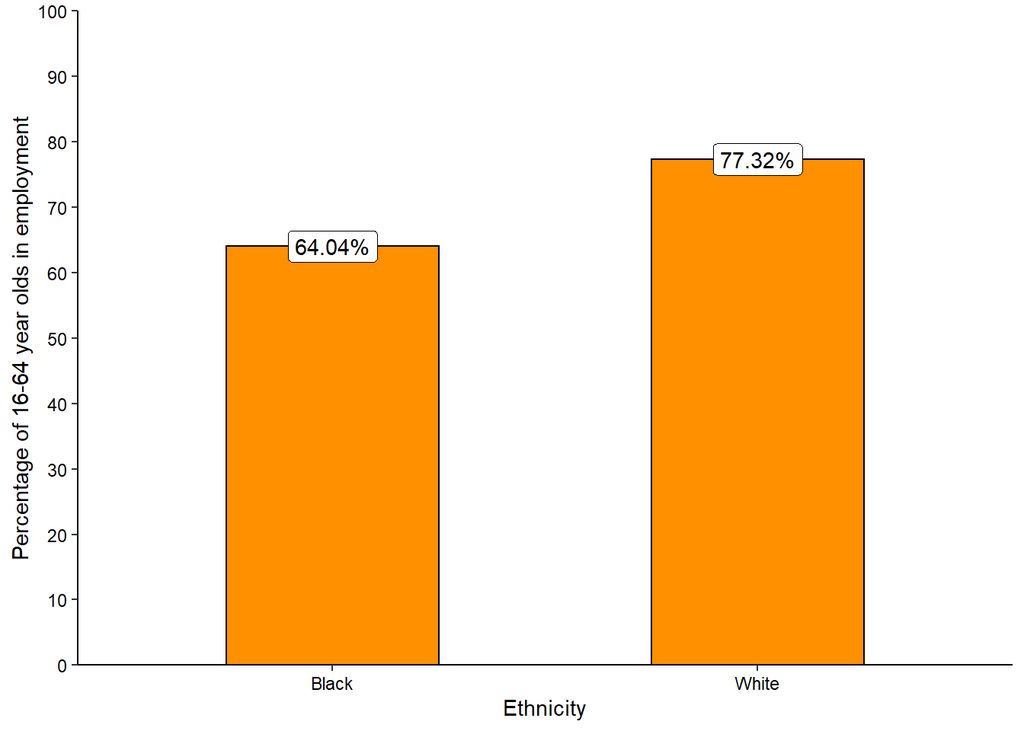

### Rate of Police Stop and Search

```r
# stop and search - self-defined
data <- read.csv("../data/haringey_stop_and_search_2020_2021_v2.csv")

# self-defined ethnicity
self_defined_freq_data <- data %>%
  group_by(SDE.Group) %>%
  summarise(
    n = n() # count frequencies
  ) %>%
  rename(
    ethnicity = SDE.Group
  ) %>%
  mutate(
    # add population estimates
    # population estimates taken from APS apr2020-mar2021
    # Asian population = sum of Indian and Pakistani/Bangladeshi pops
    # c(Asian, Black, Other, White)
    pop = c(5800, 29200, 18400, 161400),
    percentage = 100 * (n/pop),
    not_ss = pop - n
  )

self_defined_freq_data <- as.data.frame(self_defined_freq_data)
row.names(self_defined_freq_data) <- self_defined_freq_data$ethnicity

# prepare xtabs
black <- data.frame("Black" = c("ss" = self_defined_freq_data["Black", "n"], "not_ss" = self_defined_freq_data["Black", "not_ss"]))
white <- data.frame("White" = c("ss" = self_defined_freq_data["White", "n"], "not_ss" = self_defined_freq_data["White", "not_ss"]))
bw_mat <- as.matrix(cbind(black, white))
stop_search_df <- as.data.frame(bw_mat) # save df

rr <- rr_from_df(stop_search_df, "Police Stop and Search (2020-2021)")

# run analysis
xtab <- CrossTable(bw_mat, fisher = T, chisq = T, expected = T)
```

```
##
##
##    Cell Contents
## |-------------------------|
## |                       N |
## |              Expected N |
## | Chi-square contribution |
## |           N / Row Total |
## |           N / Col Total |
## |         N / Table Total |
## |-------------------------|
##
##
## Total Observations in Table:  190600
##
##
##              |     Black |     White | Row Total |
## -------------|-----------|-----------|-----------|
##           ss |      2348 |      1969 |      4317 |
##              |   661.366 |  3655.634 |           |
##              |  4301.299 |   778.178 |           |
##              |     0.544 |     0.456 |     0.023 |
##              |     0.080 |     0.012 |           |
##              |     0.012 |     0.010 |           |
## -------------|-----------|-----------|-----------|
##       not_ss |     26852 |    159431 |    186283 |
##              | 28538.634 | 157744.366 |           |
##              |    99.680 |    18.034 |           |
##              |     0.144 |     0.856 |     0.977 |
##              |     0.920 |     0.988 |           |
##              |     0.141 |     0.836 |           |
## -------------|-----------|-----------|-----------|
## Column Total |     29200 |    161400 |    190600 |
##              |     0.153 |     0.847 |           |
## -------------|-----------|-----------|-----------|
##
##
## Statistics for All Table Factors
##
##
```

[output cut: 12 more lines]

```
##
## Alternative hypothesis: true odds ratio is not equal to 1
## p =  0
## 95% confidence interval:  6.656441 7.531349
##
## Alternative hypothesis: true odds ratio is less than 1
## p =  1
## 95% confidence interval:  0 7.456663
##
## Alternative hypothesis: true odds ratio is greater than 1
## p =  0
## 95% confidence interval:  6.72313 Inf
##
##
##
```

The results indicate that in the 12 months to August 2021, there was a significant difference between Black and White individuals in the odds of being stopped and searched by Police, $\chi^{2}$(1, *N* = 190600) = 5197.19, *p* < .001. The odds of a Black individual being stopped and searched by police were 7.08 times the odds of a White individual being stopped and searched (95% CI = 6.66 - 7.53). The relative risk ratio for Black individuals compared to White individuals was 6.59 (95% CI = 6.22 - 6.99), indicating that Black individuals were 559% (i.e., 6.59 times) more likely than White individuals to be stopped and searched by Police. The plot below shows that 8.04% of Black individuals in Haringey were subject to Police Stop and Search, compared to 1.22% of White individuals.

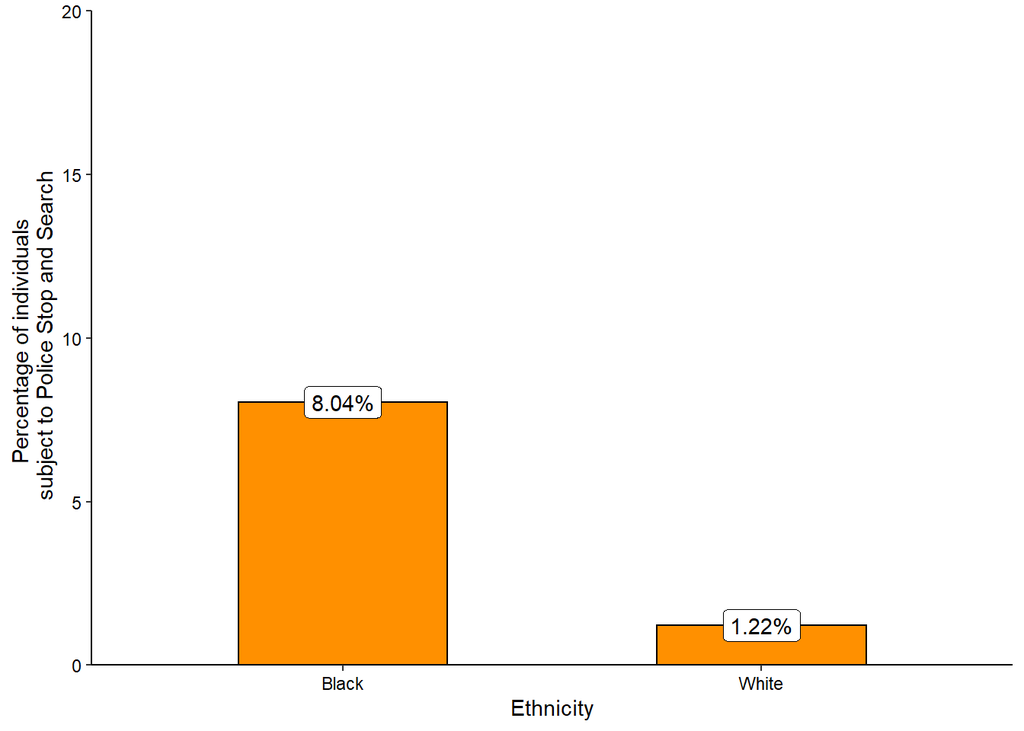

### Households that are statutorily homeless or at risk of becoming homeless

```r
# homelessness
data <- read.csv("../data/haringey_stat_homeless_2020_2021_v2.csv")

total_data <- data %>%
  subset(ethnicity == "Asian" | ethnicity == "Black" | ethnicity == "Mixed/multiple" | ethnicity == "Other" | ethnicity == "White")

total_data <- total_data[order(total_data$ethnicity),]
total_data$ethnicity <- as.factor(total_data$ethnicity)
total_data$number_homeless <- as.numeric(total_data$number_homeless)
row.names(total_data) <- total_data$ethnicity

# in homelessness dataset Chinese is included in Asian
# in population dataset it isn't. Need to account for this by taking chinese
# from asian category and adding them to other category
total_data["Asian","number_homeless"] <- total_data["Asian","number_homeless"] - 7
total_data["Other", "number_homeless"] <- total_data["Other", "number_homeless"] + 7


total_data <- total_data %>%
    mutate(
    pop = c(5800, 29200, 4400, 18400, 161400), # haringey population estimates taken from APS apr2020-mar2021
    percentage = 100 * (number_homeless/pop),
    number_not_homeless = pop - number_homeless
    )
# prepare xtab
black <- data.frame("black" = c("homeless" = total_data["Black", "number_homeless"], "not_homeless" = total_data["Black", "number_not_homeless"]))
white <- data.frame("white" = c("homeless" = total_data["White", "number_homeless"], "not_homeless" = total_data["White", "number_not_homeless"]))
bw_mat <- as.matrix(cbind(black, white))
homeless_df <- as.data.frame(bw_mat) # save df

rr <- rr_from_df(homeless_df, "Statutorily homeless or at risk (2020-2021)") # risk ratio

# run analysis
xtab <- CrossTable(bw_mat, fisher = T, chisq = T, expected = T)
```

```
##
##
##    Cell Contents
## |-------------------------|
## |                       N |
## |              Expected N |
## | Chi-square contribution |
## |           N / Row Total |
## |           N / Col Total |
## |         N / Table Total |
## |-------------------------|
##
##
## Total Observations in Table:  190600
##
##
##              |     black |     white | Row Total |
## -------------|-----------|-----------|-----------|
##     homeless |       757 |       539 |      1296 |
##              |   198.548 |  1097.452 |           |
##              |  1570.750 |   284.175 |           |
##              |     0.584 |     0.416 |     0.007 |
##              |     0.026 |     0.003 |           |
##              |     0.004 |     0.003 |           |
## -------------|-----------|-----------|-----------|
## not_homeless |     28443 |    160861 |    189304 |
##              | 29001.452 | 160302.548 |           |
##              |    10.754 |     1.946 |           |
##              |     0.150 |     0.850 |     0.993 |
##              |     0.974 |     0.997 |           |
##              |     0.149 |     0.844 |           |
## -------------|-----------|-----------|-----------|
## Column Total |     29200 |    161400 |    190600 |
##              |     0.153 |     0.847 |           |
## -------------|-----------|-----------|-----------|
##
##
## Statistics for All Table Factors
##
##
```

[output cut: 12 more lines]

```
##
## Alternative hypothesis: true odds ratio is not equal to 1
## p =  1.237517e-278
## 95% confidence interval:  7.098034 8.892578
##
## Alternative hypothesis: true odds ratio is less than 1
## p =  1
## 95% confidence interval:  0 8.735868
##
## Alternative hypothesis: true odds ratio is greater than 1
## p =  1.237517e-278
## 95% confidence interval:  7.223928 Inf
##
##
##
```

The results indicate that in the 2020-2021 financial year, there was a significant difference in the odds of being homeless or at risk of being homeless between Black and White households, $\chi^{2}$(1, *N* = 190600) = 1867.62, *p* < .001. The odds of a Black household being owed prevention or relief duty were 7.94 times the odds for a White household (95% CI = 7.1 - 8.89). The relative risk ratio for Black households compared to White households was 7.76 (95% CI = 6.96 - 8.66), indicating that Black households were 676% (i.e., 7.76 times) more likely than White households to be statutorily homeless or at risk of being so. The plot below shows that 2.59% of Black households were homeless or at risk of becoming homeless, compared to 0.33% of White households.

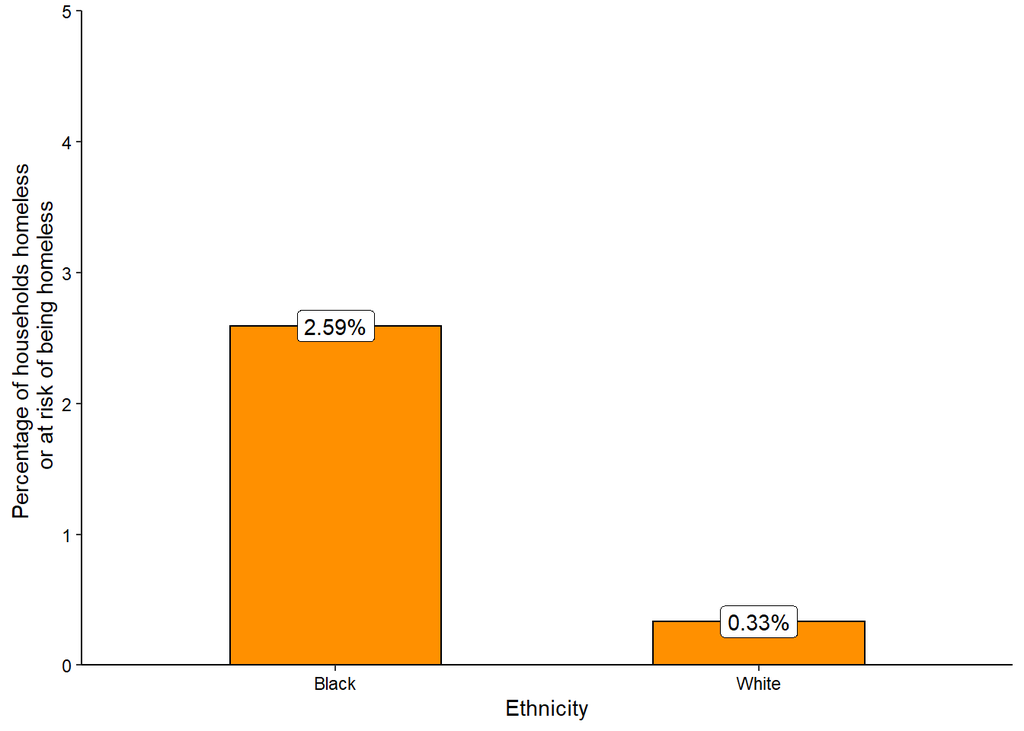

## Lambeth

### Summary

The figures and tables below visualise these results both in terms of odds ratios and relative risk ratios.

#### Relative risk ratios

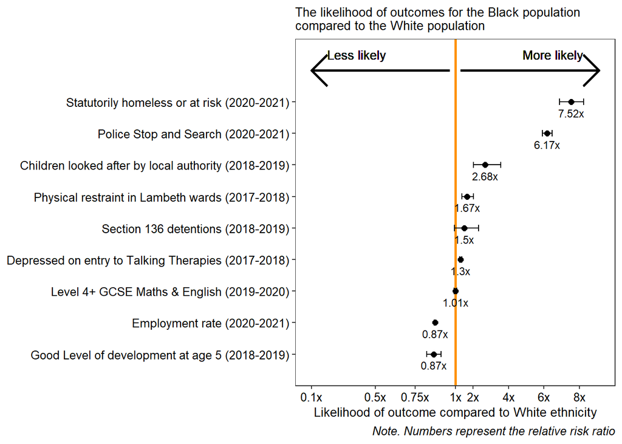

Relative risk ratios and confidence intervals corresponding to the above plot

| Indicator | Relative risk ratio | Lower confidence interval (95%) | Upper confidence interval (95%) |
| --- | --- | --- | --- |
| Statutorily homeless or at risk (2020-2021) | 7.52 | 6.87 | 8.22 |
| Police Stop and Search (2020-2021) | 6.17 | 5.90 | 6.46 |
| Children looked after by local authority (2018-2019) | 2.68 | 2.02 | 3.55 |
| Physical restraint in Lambeth wards (2017-2018) | 1.67 | 1.37 | 2.04 |
| Section 136 detentions (2018-2019) | 1.50 | 0.97 | 2.31 |
| Depressed on entry to Talking Therapies (2017-2018) | 1.30 | 1.24 | 1.37 |
| Level 4+ GCSE Maths & English (2019-2020) | 1.01 | 0.94 | 1.08 |
| Good Level of development at age 5 (2018-2019) | 0.87 | 0.82 | 0.91 |
| Employment rate (2020-2021) | 0.87 | 0.87 | 0.88 |

#### Odds ratios

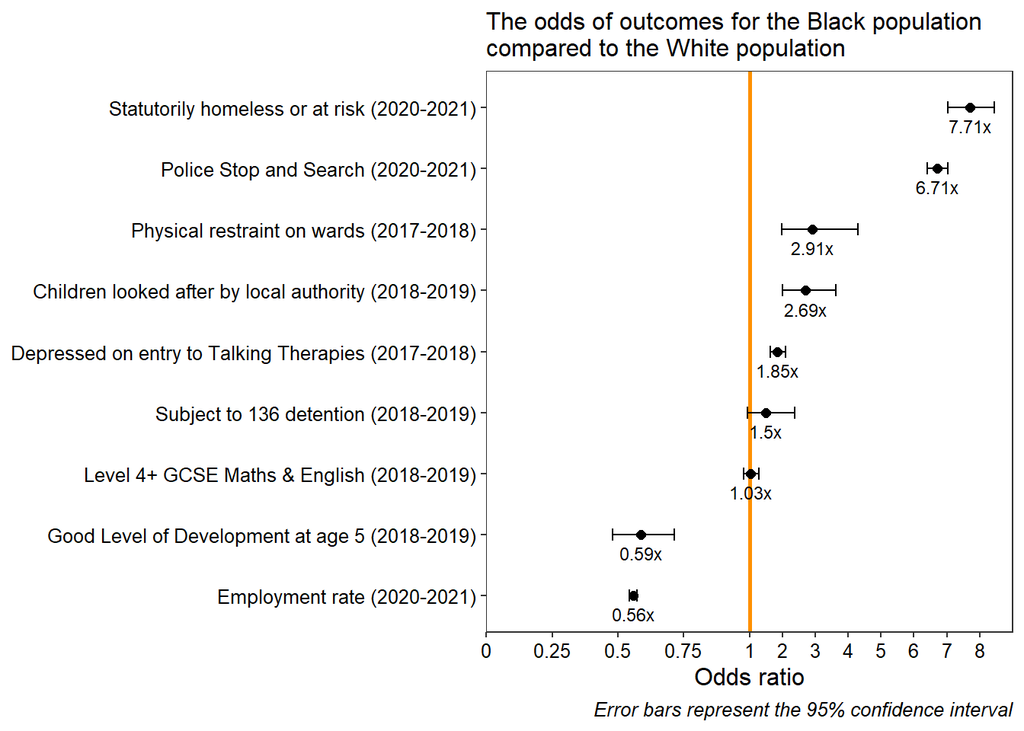

Odds ratios and confidence intervals corresponding to the above plot

| Indicator | Odds Ratio | Lower confidence interval (95%) | Upper confidence interval (95%) |
| --- | --- | --- | --- |
| Statutorily homeless or at risk (2020-2021) | 7.71 | 7.03 | 8.45 |
| Police Stop and Search (2020-2021) | 6.71 | 6.40 | 7.04 |
| Physical restraint on wards (2017-2018) | 2.91 | 1.98 | 4.30 |
| Children looked after by local authority (2018-2019) | 2.69 | 2.01 | 3.63 |
| Depressed on entry to Talking Therapies (2017-2018) | 1.85 | 1.63 | 2.11 |
| Subject to 136 detention (2018-2019) | 1.50 | 0.95 | 2.37 |
| Level 4+ GCSE Maths & English (2018-2019) | 1.03 | 0.83 | 1.29 |
| Good Level of Development at age 5 (2018-2019) | 0.59 | 0.48 | 0.71 |
| Employment rate (2020-2021) | 0.56 | 0.54 | 0.57 |

### Children achieving Good Level of Development

```r
## good development
data <- read.csv("../data/lambeth_gld_2018_2019.csv")

total_data <- data
total_data$ethnicity <- as.factor(total_data$ethnicity)
levels(total_data$ethnicity) <- c("Black","White")

row.names(total_data) <- total_data$ethnicity # set row names for indexing

# prepare data frame for crosstabs

black <- data.frame("black" = c("gld_number" = total_data["Black", "gld"], "not_gld_number" = total_data["Black", "not_gld"]))

white <- data.frame("white" = c("gld_number" = total_data["White", "gld"], "not_gld_number" =  total_data["White", "not_gld"]))

bw_mat <- as.matrix(cbind(black, white)) # combine black and white into one matrix

gld_df <- as.data.frame(bw_mat) # save df

rr <- rr_from_df(gld_df, "Good Level of development at age 5 (2018-2019)")
xtab <- CrossTable(bw_mat, fisher = T, chisq = T, expected = T) # save xtab
```

```
##
##
##    Cell Contents
## |-------------------------|
## |                       N |
## |              Expected N |
## | Chi-square contribution |
## |           N / Row Total |
## |           N / Col Total |
## |         N / Table Total |
## |-------------------------|
##
##
## Total Observations in Table:  2122
##
##
##                |     black |     white | Row Total |
## ---------------|-----------|-----------|-----------|
##     gld_number |       678 |       871 |      1549 |
##                |   733.622 |   815.378 |           |
##                |     4.217 |     3.794 |           |
##                |     0.438 |     0.562 |     0.730 |
##                |     0.675 |     0.780 |           |
##                |     0.320 |     0.410 |           |
## ---------------|-----------|-----------|-----------|
## not_gld_number |       327 |       246 |       573 |
##                |   271.378 |   301.622 |           |
##                |    11.400 |    10.257 |           |
##                |     0.571 |     0.429 |     0.270 |
##                |     0.325 |     0.220 |           |
##                |     0.154 |     0.116 |           |
## ---------------|-----------|-----------|-----------|
##   Column Total |      1005 |      1117 |      2122 |
##                |     0.474 |     0.526 |           |
## ---------------|-----------|-----------|-----------|
##
##
## Statistics for All Table Factors
##
##
```

[output cut: 12 more lines]

```
##
## Alternative hypothesis: true odds ratio is not equal to 1
## p =  0.00000005278876
## 95% confidence interval:  0.4801734 0.7138803
##
## Alternative hypothesis: true odds ratio is less than 1
## p =  0.00000003347373
## 95% confidence interval:  0 0.6921203
##
## Alternative hypothesis: true odds ratio is greater than 1
## p =  1
## 95% confidence interval:  0.4954103 Inf
##
##
##
```

The results indicate that in Lambeth there was a significant difference between Black children and White children in the odds of achieving a Good Level of Development at age 5, $\chi^{2}$(1, *N* = 2122) = 29.67, *p* < .001. The odds of a Black child reaching a Good Level of Development were 0.59 times the odds for a White child (95% CI = 0.48 - 0.71). The relative risk ratio for Black children compared to White children was 0.87 (95% CI = 0.82 - 0.91), indicating that Black children were 13.48% less likely than White children to reach a Good Level of Development at age 5. The plot below shows that 67.46% of Black children and 77.98% of White children reached a Good Level of Development in 2018-2019.

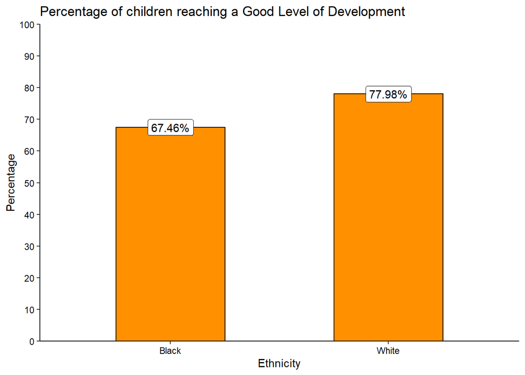

### Pupils achieving at least Level 4 in GCSE Maths and English

```r
data <- read.csv("../data/lambeth_gcse_2019_2020.csv")

# subset and rename
total_data <- data %>%
  subset(characteristic_gender == "Total") %>%
  rename(
    ethnicity = characteristic_Ethnic_major
  ) %>%
  subset(ethnicity == "BLACK" | ethnicity == "WHITE") %>%
  rename(gcse = t_l2basics_94,
         percent_gcse = pt_l2basics_94)

# rename ethnicity levels and row names
total_data$ethnicity <- as.factor(total_data$ethnicity)
levels(total_data$ethnicity) <- c("Black","White")
row.names(total_data) <- total_data$ethnicity

total_data <- total_data[,-c(1)] # remove unnecessary column

# calculate number who didn't achieve level 4 plus
total_data <- total_data %>%
  mutate(
    not_gcse = t_pupils - gcse
  )

# prepare data frame for xtab
black <- data.frame("black" = c("gcse" = total_data["Black", "gcse"], "not_gcse" = total_data["Black", "not_gcse"]))
white <- data.frame("white" = c("gcse" = total_data["White", "gcse"], "not_gcse" = total_data["White", "not_gcse"]))
bw_mat <- as.matrix(cbind(black, white))

gcse_df <- as.data.frame(bw_mat) # save df

# run stats
rr <- rr_from_df(gcse_df, "Level 4+ GCSE Maths & English (2019-2020)")
xtab <- CrossTable(bw_mat, fisher = T, chisq = T, expected = T)
```

```
##
##
##    Cell Contents
## |-------------------------|
## |                       N |
## |              Expected N |
## | Chi-square contribution |
## |           N / Row Total |
## |           N / Col Total |
## |         N / Table Total |
## |-------------------------|
##
##
## Total Observations in Table:  1647
##
##
##              |     black |     white | Row Total |
## -------------|-----------|-----------|-----------|
##         gcse |       737 |       384 |      1121 |
##              |   734.401 |   386.599 |           |
##              |     0.009 |     0.017 |           |
##              |     0.657 |     0.343 |     0.681 |
##              |     0.683 |     0.676 |           |
##              |     0.447 |     0.233 |           |
## -------------|-----------|-----------|-----------|
##     not_gcse |       342 |       184 |       526 |
##              |   344.599 |   181.401 |           |
##              |     0.020 |     0.037 |           |
##              |     0.650 |     0.350 |     0.319 |
##              |     0.317 |     0.324 |           |
##              |     0.208 |     0.112 |           |
## -------------|-----------|-----------|-----------|
## Column Total |      1079 |       568 |      1647 |
##              |     0.655 |     0.345 |           |
## -------------|-----------|-----------|-----------|
##
##
## Statistics for All Table Factors
##
##
```

[output cut: 12 more lines]

```
##
## Alternative hypothesis: true odds ratio is not equal to 1
## p =  0.7812103
## 95% confidence interval:  0.8251192 1.290387
##
## Alternative hypothesis: true odds ratio is less than 1
## p =  0.6354552
## 95% confidence interval:  0 1.246382
##
## Alternative hypothesis: true odds ratio is greater than 1
## p =  0.4069917
## 95% confidence interval:  0.8547118 Inf
##
##
##
```

The results indicate that in the 2019-2020 academic year, there was no statistically significant difference between Black pupils and White pupils in the odds of achieving at least a Level 4 in GCSE Maths and English, $\chi^{2}$(1, *N* = 1647) = 0.08, *p* = 0.773. The plot below shows that 68.3% of Black pupils achieved at least Level 4 in English and Maths, compared to 67.6% of White pupils.

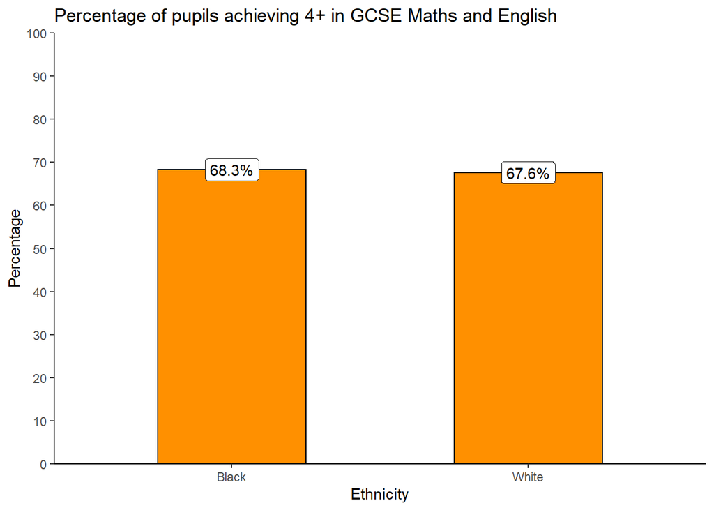

### Children looked after by the local authority

```r
# children looked after
data <- read.csv("../data/lambeth_cla_2019.csv")

total_data <- data
total_data$ethnicity <- as.factor(total_data$ethnicity)
levels(total_data$ethnicity) <- c("Black","White")

row.names(total_data) <- total_data$ethnicity

# prepare xtab
black <- data.frame("black" = c("looked_after" = total_data["Black", "looked_after"], "not_looked_after" = total_data["Black", "not_looked_after"]))
white <- data.frame("white" = c("looked_after" = total_data["White", "looked_after"], "not_looked_after" = total_data["White", "not_looked_after"]))
bw_mat <- as.matrix(cbind(black, white))

cla_df <- as.data.frame(bw_mat) # save df

# run analysis
rr <- rr_from_df(cla_df, "Children looked after by local authority (2018-2019)")
xtab <- CrossTable(bw_mat, fisher = T, chisq = T, expected = T)
```

```
##
##
##    Cell Contents
## |-------------------------|
## |                       N |
## |              Expected N |
## | Chi-square contribution |
## |           N / Row Total |
## |           N / Col Total |
## |         N / Table Total |
## |-------------------------|
##
##
## Total Observations in Table:  47046
##
##
##                  |     black |     white | Row Total |
## -----------------|-----------|-----------|-----------|
##     looked_after |       178 |        65 |       243 |
##                  |   122.874 |   120.126 |           |
##                  |    24.732 |    25.297 |           |
##                  |     0.733 |     0.267 |     0.005 |
##                  |     0.007 |     0.003 |           |
##                  |     0.004 |     0.001 |           |
## -----------------|-----------|-----------|-----------|
## not_looked_after |     23611 |     23192 |     46803 |
##                  | 23666.126 | 23136.874 |           |
##                  |     0.128 |     0.131 |           |
##                  |     0.504 |     0.496 |     0.995 |
##                  |     0.993 |     0.997 |           |
##                  |     0.502 |     0.493 |           |
## -----------------|-----------|-----------|-----------|
##     Column Total |     23789 |     23257 |     47046 |
##                  |     0.506 |     0.494 |           |
## -----------------|-----------|-----------|-----------|
##
##
## Statistics for All Table Factors
##
##
```

[output cut: 12 more lines]

```
##
## Alternative hypothesis: true odds ratio is not equal to 1
## p =  6.125754e-13
## 95% confidence interval:  2.012709 3.633445
##
## Alternative hypothesis: true odds ratio is less than 1
## p =  1
## 95% confidence interval:  0 3.463034
##
## Alternative hypothesis: true odds ratio is greater than 1
## p =  3.887979e-13
## 95% confidence interval:  2.103245 Inf
##
##
##
```

The results indicate that, in the 2018-2019 financial year, there was a significant relationship between child ethnicity and the odds of being looked after the local authority, $\chi^{2}$(1, *N* = 47046) = 50.29, *p* < .001. The odds of Black children being looked after by the local authority were 2.69 times the odds for White children (95% CI = 2.01 - 3.63). The relative risk ratio for Black children compared to White children was 2.68 (95% CI = 2.02 - 3.55), indicating that Black children were 168% (i.e., 2.68 times) more likely than White children to be looked after by the local authority. The plot below shows that 0.75% of Black children, compared to 0.28% of White children, were looked after by the local authority in the 2018-2019 financial year.

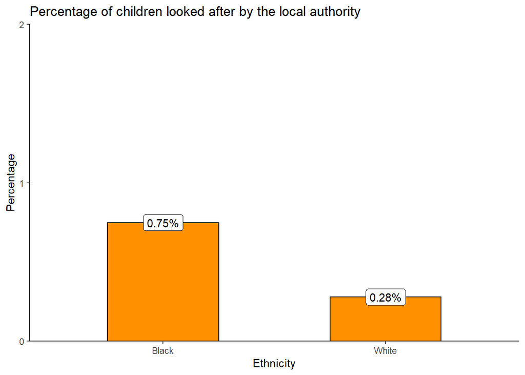

### Employment

```r
# employment
data <- read.csv("../data/lambeth_employment_rate_march_2021_v2.csv")

# subset and organise data
total_data <- data %>%
  mutate(
    percentage = as.numeric(percentage),
    numerator = as.numeric(numerator),
    denominator = as.numeric(denominator)
  )

row.names(total_data) <- total_data$ethnicity

# prepare xtab
black <- data.frame("black" = c("employed" = total_data["black", "numerator"], "not_employed" = total_data["black", "not_employed"]))
white <- data.frame("white" = c("employed" = total_data["white", "numerator"], "not_employed" = total_data["white", "not_employed"]))
bw_mat <- as.matrix(cbind(black, white))

employment_df <- as.data.frame(bw_mat) # save df

# run analysis
rr <- rr_from_df(employment_df, "Employment rate (2020-2021)")
xtab <- CrossTable(bw_mat, fisher = T, chisq = T, expected = T)
```

```
##
##
##    Cell Contents
## |-------------------------|
## |                       N |
## |              Expected N |
## | Chi-square contribution |
## |           N / Row Total |
## |           N / Col Total |
## |         N / Table Total |
## |-------------------------|
##
##
## Total Observations in Table:  198500
##
##
##              |     black |     white | Row Total |
## -------------|-----------|-----------|-----------|
##     employed |     24300 |    134500 |    158800 |
##              | 27200.000 | 131600.000 |           |
##              |   309.191 |    63.906 |           |
##              |     0.153 |     0.847 |     0.800 |
##              |     0.715 |     0.818 |           |
##              |     0.122 |     0.678 |           |
## -------------|-----------|-----------|-----------|
## not_employed |      9700 |     30000 |     39700 |
##              |  6800.000 | 32900.000 |           |
##              |  1236.765 |   255.623 |           |
##              |     0.244 |     0.756 |     0.200 |
##              |     0.285 |     0.182 |           |
##              |     0.049 |     0.151 |           |
## -------------|-----------|-----------|-----------|
## Column Total |     34000 |    164500 |    198500 |
##              |     0.171 |     0.829 |           |
## -------------|-----------|-----------|-----------|
##
##
## Statistics for All Table Factors
##
##
```

[output cut: 12 more lines]

```
##
## Alternative hypothesis: true odds ratio is not equal to 1
## p =  0
## 95% confidence interval:  0.544038 0.5739264
##
## Alternative hypothesis: true odds ratio is less than 1
## p =  0
## 95% confidence interval:  0 0.5715026
##
## Alternative hypothesis: true odds ratio is greater than 1
## p =  1
## 95% confidence interval:  0.5463672 Inf
##
##
##
```

```r
#chisq.test(bw_mat)
```

The results indicate that in the 12 months to March 2021, there was a significant difference between Black and White 16-64 year olds in the odds of being employed, $\chi^{2}$(1, *N* = 198500) = 1865.48, *p* < .001. The odds of Black 16-64 year olds being employed were 0.56 times the odds of White 16-64 year olds being employed (95% CI = 0.54 - 0.57). The relative risk ratio for Black individuals compared to White individuals was 0.87 (95% CI = 0.87 - 0.88), indicating that Black 16-64 year olds were 12.59% less likely than White 16-64 year olds to be in employment. The plot below shows that 71.47% of Black 16-64 year olds were employed in the 12 months to March 2021, compared to 81.76% of White 16-64 year olds.

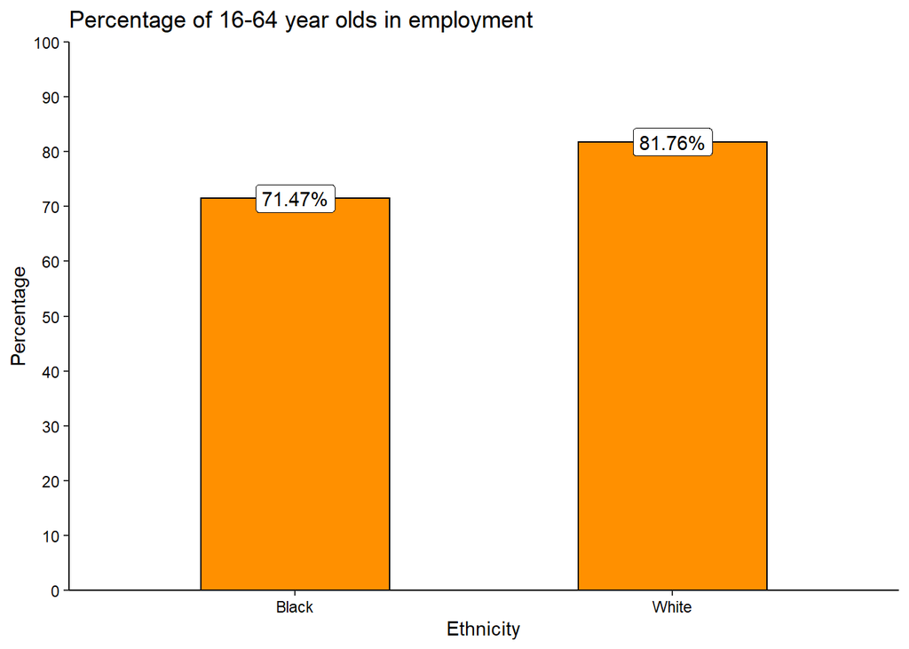

### Rate of Police Stop and Search

```r
# stop and search
data <- read.csv("../data/Stops_LDS_Extract_12MonthsToEnd_202108.csv")

data <- subset(data, Borough.of.Stop == "Lambeth") # subset to Lambeth

# officer-defined ethnicity
self_defined_freq_data <- data %>%
  group_by(SDE.Group) %>%
  summarise(
    stopped = n() # count frequencies
  )

self_defined_freq_data <- self_defined_freq_data %>%
  mutate(
    pop = c(6500, 54600, 26700, 177400), # Lambeth population estimates taken from APS 12 months to Jun 2021
    percentage = 100 * (stopped/pop),
    not_stopped = pop - stopped
    ) %>%
  rename(
    ethnicity = SDE.Group
  )

self_defined_freq_data <- as.data.frame(self_defined_freq_data)
row.names(self_defined_freq_data) <- self_defined_freq_data$ethnicity

black <- data.frame("Black" = c("stopped" = self_defined_freq_data["Black", "stopped"], "not_stopped" = self_defined_freq_data["Black", "not_stopped"]))

white <- data.frame("White" = c("stopped" = self_defined_freq_data["White", "stopped"], "not_stopped" = self_defined_freq_data["White", "not_stopped"]))

bw_mat <- as.matrix(cbind(black, white))

stop_search_df <- as.data.frame(bw_mat) # save df

# run analysis
rr<- rr_from_df(stop_search_df, "Police Stop and Search (2020-2021)")
xtab <- CrossTable(bw_mat, chisq = T, fisher = T, expected = T)
```

```
##
##
##    Cell Contents
## |-------------------------|
## |                       N |
## |              Expected N |
## | Chi-square contribution |
## |           N / Row Total |
## |           N / Col Total |
## |         N / Table Total |
## |-------------------------|
##
##
## Total Observations in Table:  232000
##
##
##              |     Black |     White | Row Total |
## -------------|-----------|-----------|-----------|
##      stopped |      5180 |      2727 |      7907 |
##              |  1860.872 |  6046.128 |           |
##              |  5920.137 |  1822.094 |           |
##              |     0.655 |     0.345 |     0.034 |
##              |     0.095 |     0.015 |           |
##              |     0.022 |     0.012 |           |
## -------------|-----------|-----------|-----------|
##  not_stopped |     49420 |    174673 |    224093 |
##              | 52739.128 | 171353.872 |           |
##              |   208.889 |    64.292 |           |
##              |     0.221 |     0.779 |     0.966 |
##              |     0.905 |     0.985 |           |
##              |     0.213 |     0.753 |           |
## -------------|-----------|-----------|-----------|
## Column Total |     54600 |    177400 |    232000 |
##              |     0.235 |     0.765 |           |
## -------------|-----------|-----------|-----------|
##
##
## Statistics for All Table Factors
##
##
```

[output cut: 12 more lines]

```
##
## Alternative hypothesis: true odds ratio is not equal to 1
## p =  0
## 95% confidence interval:  6.401421 7.040929
##
## Alternative hypothesis: true odds ratio is less than 1
## p =  1
## 95% confidence interval:  0 6.987645
##
## Alternative hypothesis: true odds ratio is greater than 1
## p =  0
## 95% confidence interval:  6.449954 Inf
##
##
##
```

The results indicate that in the 12 months to August 2021, there was a significant difference between Black and White individuals in the odds of being stopped and searched by Police, $\chi^{2}$(1, *N* = 232000) = 8015.41, *p* < .001. The odds of a Black individual being stopped and searched by police were 6.71 times the odds of a White individual being stopped and searched (95% CI = 6.4 - 7.04). The relative risk ratio for Black individuals compared to White individuals was 6.17 (95% CI = 5.9 - 6.46), indicating that Black individuals were 517% (i.e., 6.17 times) more likely than White individuals to be stopped and searched by Police. The plot below shows that 9.49% of Black individuals were subject to Police Stop and Search, compared to 1.54% of White individuals.

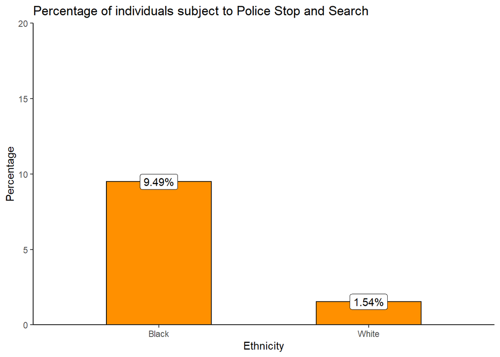

### Households that are statutorily homeless or at risk of becoming homeless

```r
# homelessness
data <- read.csv("../data/lambeth_stat_homeless_jun_2021.csv")

total_data <- data

total_data$ethnicity <- as.factor(total_data$ethnicity)
row.names(total_data) <- total_data$ethnicity

# prepare xtab
black <- data.frame("black" = c("homeless" = total_data["black", "homeless"], "not_homeless" = total_data["black", "not_homeless"]))
white <- data.frame("white" = c("homeless" = total_data["white", "homeless"], "not_homeless" = total_data["white", "not_homeless"]))
bw_mat <- as.matrix(cbind(black, white))

homelessness_df <- as.data.frame(bw_mat) # save df

# run analysis
rr <- rr_from_df(homelessness_df, "Statutorily homeless or at risk (2020-2021)")
xtab <- CrossTable(bw_mat, fisher = T, chisq = T, expected = T)
```

```
##
##
##    Cell Contents
## |-------------------------|
## |                       N |
## |              Expected N |
## | Chi-square contribution |
## |           N / Row Total |
## |           N / Col Total |
## |         N / Table Total |
## |-------------------------|
##
##
## Total Observations in Table:  232000
##
##
##              |     black |     white | Row Total |
## -------------|-----------|-----------|-----------|
##     homeless |      1552 |       671 |      2223 |
##              |   523.172 |  1699.828 |           |
##              |  2023.214 |   622.703 |           |
##              |     0.698 |     0.302 |     0.010 |
##              |     0.028 |     0.004 |           |
##              |     0.007 |     0.003 |           |
## -------------|-----------|-----------|-----------|
## not_homeless |     53048 |    176729 |    229777 |
##              | 54076.828 | 175700.172 |           |
##              |    19.574 |     6.024 |           |
##              |     0.231 |     0.769 |     0.990 |
##              |     0.972 |     0.996 |           |
##              |     0.229 |     0.762 |           |
## -------------|-----------|-----------|-----------|
## Column Total |     54600 |    177400 |    232000 |
##              |     0.235 |     0.765 |           |
## -------------|-----------|-----------|-----------|
##
##
## Statistics for All Table Factors
##
##
```

[output cut: 12 more lines]

```
##
## Alternative hypothesis: true odds ratio is not equal to 1
## p =  0
## 95% confidence interval:  7.030583 8.45157
##
## Alternative hypothesis: true odds ratio is less than 1
## p =  1
## 95% confidence interval:  0 8.328274
##
## Alternative hypothesis: true odds ratio is greater than 1
## p =  0
## 95% confidence interval:  7.132956 Inf
##
##
##
```

```r
#chisq.test(bw_mat)
```

The results indicate that in the 2020-2021 financial year, there was a significant difference in the odds of being homeless or at risk of being homeless between Black and White households, $\chi^{2}$(1, *N* = 232000) = 2671.51, *p* < .001. The odds of a Black household being owed prevention or relief duty were 7.71 times the odds for a White household (95% CI = 7.03 - 8.45). The relative risk ratio for Black households compared to White households was 7.52 (95% CI = 6.87 - 8.22), indicating that Black households were 652% (i.e., 7.52 times) more likely than White households to be statutorily homeless or at risk of being so. The plot below shows that 2.84% of Black households were homeless or at risk of becoming homeless, compared to 0.38% of White households.

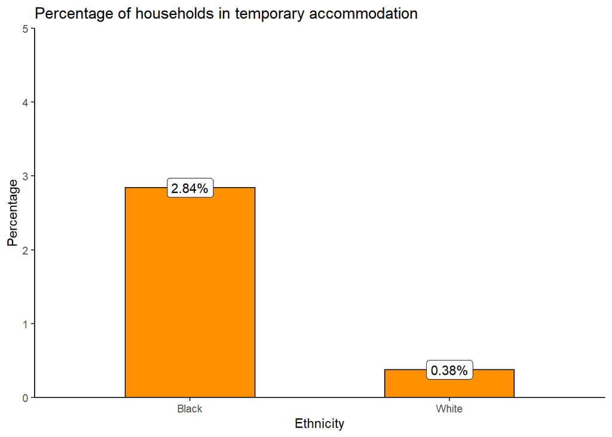

### Moderate to severe depression on entry to Talking Therapies

```r
b <- data.frame("black" = c(1020,550))
w <- data.frame("white" = c(1563,1563))
df <- cbind(b,w)
rownames(df) <- c("sev dep on entry","not sev dep on entry")
mat <- as.matrix(df)


talking_therapies_df <- df # save df

# run analysis.
rr<- rr_from_df(talking_therapies_df, "Depressed on entry to Talking Therapies (2017-2018)")
xtab <- CrossTable(mat, chisq = T, fisher = T, expected = T)
```

```
##
##
##    Cell Contents
## |-------------------------|
## |                       N |
## |              Expected N |
## | Chi-square contribution |
## |           N / Row Total |
## |           N / Col Total |
## |         N / Table Total |
## |-------------------------|
##
##
## Total Observations in Table:  4696
##
##
##                      |     black |     white | Row Total |
## ---------------------|-----------|-----------|-----------|
##     sev dep on entry |      1020 |      1563 |      2583 |
##                      |   863.567 |  1719.433 |           |
##                      |    28.337 |    14.232 |           |
##                      |     0.395 |     0.605 |     0.550 |
##                      |     0.650 |     0.500 |           |
##                      |     0.217 |     0.333 |           |
## ---------------------|-----------|-----------|-----------|
## not sev dep on entry |       550 |      1563 |      2113 |
##                      |   706.433 |  1406.567 |           |
##                      |    34.641 |    17.398 |           |
##                      |     0.260 |     0.740 |     0.450 |
##                      |     0.350 |     0.500 |           |
##                      |     0.117 |     0.333 |           |
## ---------------------|-----------|-----------|-----------|
##         Column Total |      1570 |      3126 |      4696 |
##                      |     0.334 |     0.666 |           |
## ---------------------|-----------|-----------|-----------|
##
##
## Statistics for All Table Factors
##
##
```

[output cut: 12 more lines]

```
##
## Alternative hypothesis: true odds ratio is not equal to 1
## p =  1.73847e-22
## 95% confidence interval:  1.633247 2.106287
##
## Alternative hypothesis: true odds ratio is less than 1
## p =  1
## 95% confidence interval:  0 2.064158
##
## Alternative hypothesis: true odds ratio is greater than 1
## p =  8.897228e-23
## 95% confidence interval:  1.666394 Inf
##
##
##
```

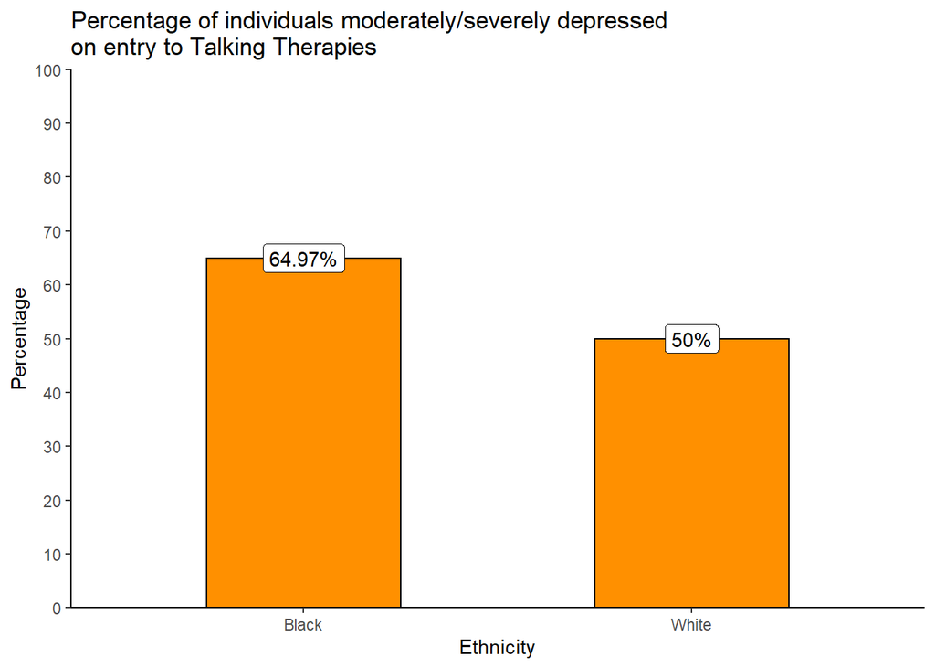

### Individuals subject to detention per Section 136 of the Mental Health Act

```r
b <- data.frame("black" = c(38,63296))
w <- data.frame("white" = c(44,109956))
df <- cbind(b,w)
rownames(df) <- c("detained","not detained")
mat <- as.matrix(df)

sect_136_df <- df # save df

# run analysis
rr <- rr_from_df(sect_136_df, "Section 136 detentions (2018-2019)")
xtab <- CrossTable(mat, chisq = T, fisher = T, expected = T)
```

```
##
##
##    Cell Contents
## |-------------------------|
## |                       N |
## |              Expected N |
## | Chi-square contribution |
## |           N / Row Total |
## |           N / Col Total |
## |         N / Table Total |
## |-------------------------|
##
##
## Total Observations in Table:  173334
##
##
##              |     black |     white | Row Total |
## -------------|-----------|-----------|-----------|
##     detained |        38 |        44 |        82 |
##              |    29.962 |    52.038 |           |
##              |     2.157 |     1.242 |           |
##              |     0.463 |     0.537 |     0.000 |
##              |     0.001 |     0.000 |           |
##              |     0.000 |     0.000 |           |
## -------------|-----------|-----------|-----------|
## not detained |     63296 |    109956 |    173252 |
##              | 63304.038 | 109947.962 |           |
##              |     0.001 |     0.001 |           |
##              |     0.365 |     0.635 |     1.000 |
##              |     0.999 |     1.000 |           |
##              |     0.365 |     0.634 |           |
## -------------|-----------|-----------|-----------|
## Column Total |     63334 |    110000 |    173334 |
##              |     0.365 |     0.635 |           |
## -------------|-----------|-----------|-----------|
##
##
## Statistics for All Table Factors
##
##
```

[output cut: 12 more lines]

```
##
## Alternative hypothesis: true odds ratio is not equal to 1
## p =  0.06734415
## 95% confidence interval:  0.945725 2.369951
##
## Alternative hypothesis: true odds ratio is less than 1
## p =  0.9735698
## 95% confidence interval:  0 2.210731
##
## Alternative hypothesis: true odds ratio is greater than 1
## p =  0.04336126
## 95% confidence interval:  1.015459 Inf
##
##
##
```

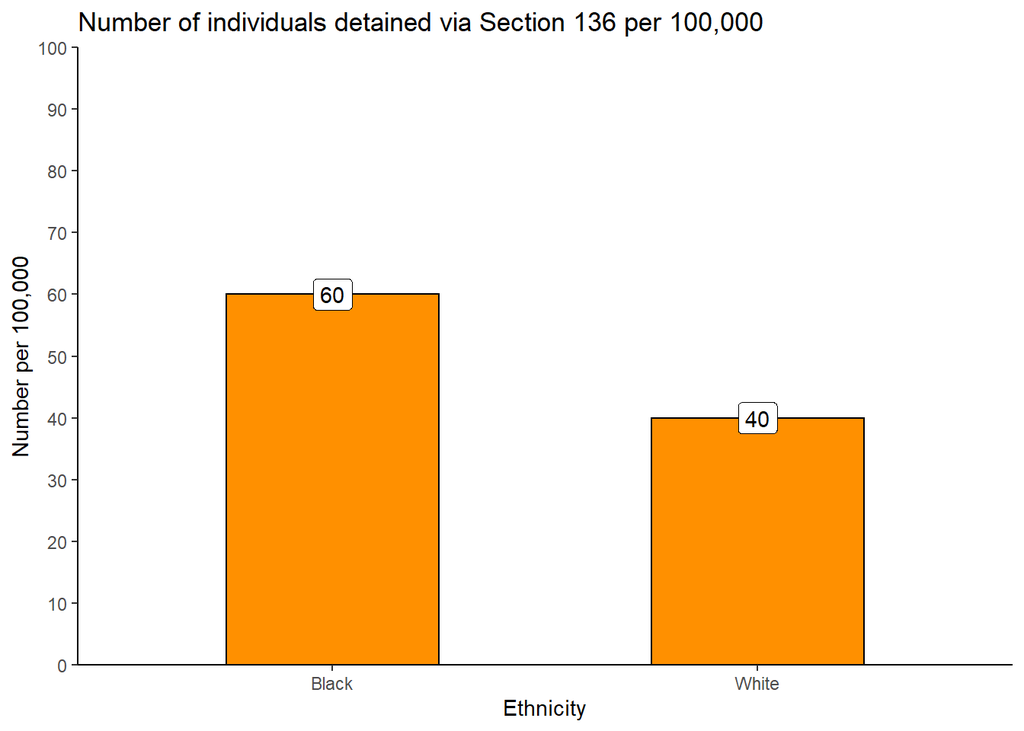

### Individuals physically restrained on Lambeth Wards

```r
b <- data.frame("black" = c(228,123))
w <- data.frame("white" = c(70,110))
df <- cbind(b,w)
rownames(df) <- c("restraint","not restraint")
mat <- as.matrix(df)

restraint_df <- df # save df

# run analysis
rr <- rr_from_df(restraint_df, "Physical restraint in Lambeth wards (2017-2018)")
xtab <- CrossTable(mat, chisq = T, fisher = T, expected = T)
```

```
##
##
##    Cell Contents
## |-------------------------|
## |                       N |
## |              Expected N |
## | Chi-square contribution |
## |           N / Row Total |
## |           N / Col Total |
## |         N / Table Total |
## |-------------------------|
##
##
## Total Observations in Table:  531
##
##
##               |     black |     white | Row Total |
## --------------|-----------|-----------|-----------|
##     restraint |       228 |        70 |       298 |
##               |   196.983 |   101.017 |           |
##               |     4.884 |     9.524 |           |
##               |     0.765 |     0.235 |     0.561 |
##               |     0.650 |     0.389 |           |
##               |     0.429 |     0.132 |           |
## --------------|-----------|-----------|-----------|
## not restraint |       123 |       110 |       233 |
##               |   154.017 |    78.983 |           |
##               |     6.246 |    12.180 |           |
##               |     0.528 |     0.472 |     0.439 |
##               |     0.350 |     0.611 |           |
##               |     0.232 |     0.207 |           |
## --------------|-----------|-----------|-----------|
##  Column Total |       351 |       180 |       531 |
##               |     0.661 |     0.339 |           |
## --------------|-----------|-----------|-----------|
##
##
## Statistics for All Table Factors
##
##
```

[output cut: 12 more lines]

```
##
## Alternative hypothesis: true odds ratio is not equal to 1
## p =  0.00000001389734
## 95% confidence interval:  1.976028 4.298545
##
## Alternative hypothesis: true odds ratio is less than 1
## p =  1
## 95% confidence interval:  0 4.045355
##
## Alternative hypothesis: true odds ratio is greater than 1
## p =  0.000000008449969
## 95% confidence interval:  2.095536 Inf
##
##
##
```

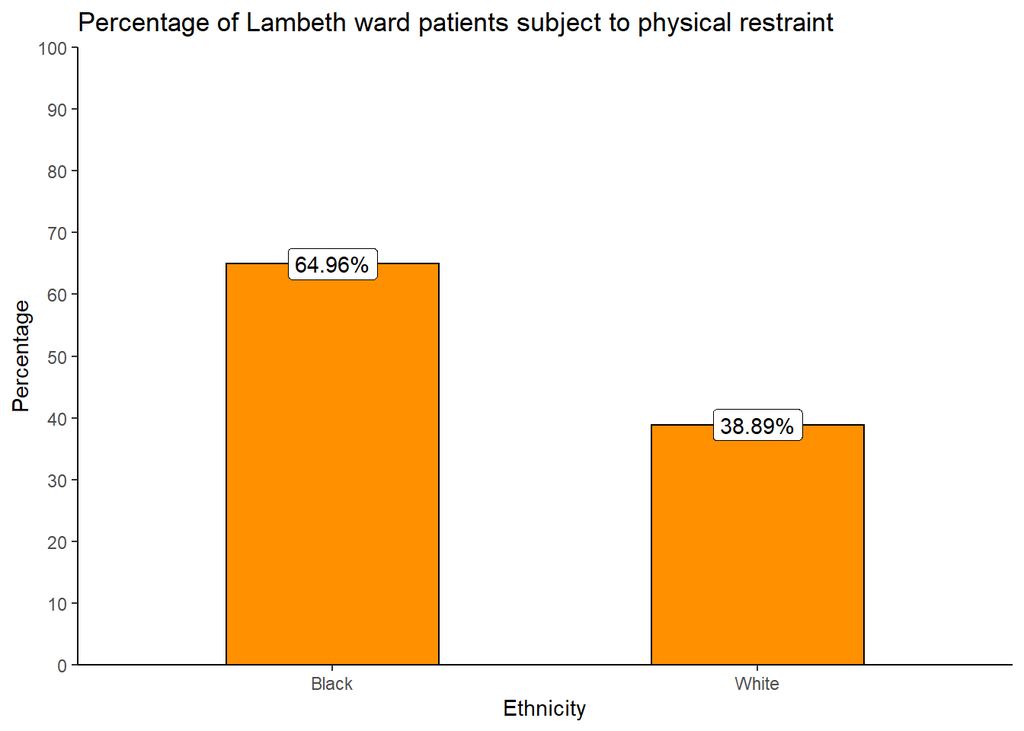

# Limitations

A notable limitation of the present analyses is the coarseness of the ethnicity categories. Nearly all of the data considered have aggregated ethnicity in broad categories and it has not been possible to examine how outcomes vary between different Black populations, such as Black African and Black Caribbean populations.

All the analyses here presented do not control for other factors that may be important for outcomes, such as age, sex, and income. Future versions of the Shared Measurement System should will take account of these potentially relevant factors in order to provide a more accurate picture of the inequality experienced by the Black population.

The mental health data for Lambeth are relatively old, meaning that it was not possible to produce a more up-to-date picture of mental health outcomes for the Black population. We aim to address this in future versions by acquiring more recent data for mental health indicators for all dashboards.

The child population estimates drawn from the Census 2011 that supplemented the children looked after by the local authority in Birmingham are very outdated, which has the effect of reducing the accuracy of the statistics associated with this indicator. Similarly, in the Stop and Search analyses, the population statistics are over-inclusive, because they include individuals who are extremely unlikely to be subject to Stop and Search (e.g., children younger than 6 years old). This has the effect of underestimating the disparities in Stop and Search rates between ethnic groups.

Furthermore, considering that the goal of the Stop and Search analysis is to investigate racism, it may be more appropriate to use officer-defined ethnicity rather than self-defined ethnicity, since unequal treatment stems from *perceptions* of ethnic categories (though this will often correlate with an individual’s self-defined ethnicity). As has been detailed in the *Data* section, an analysis based on officer-defined ethnicity was not possible for Birmingham because of significant differences in data quality (specifically the completeness of officer-defined ethnicity). It is not clear why there is such variation in the completeness of data between the Metropolitan and West Midlands Police Forces. For ease of comparison, the Haringey and Lambeth analyses were not based on officer-defined ethnicity either.

# Authors

This document was produced by the Research Team at Black Thrive Global:

**Jolyon Miles-Wilson**

**Dr Celestin Okoroji**

Any questions, comments, and/or feedback on any aspect of this analysis are greatly appreciated. Please contact us at research@blackthrive.org, FAO Jolyon Miles-Wilson.

# Supplementary materials

The code and data used to create this methodology paper are available on Github [here](https://github.com/BlackThrive/sms_methodology).

# References

Davies, Huw Talfryn Oakley, Iain Kinloch Crombie, and Manouche Tavakoli. 1998. “When Can Odds Ratios Mislead?” *BMJ : British Medical Journal* 316 (7136): 989–91. https://www.ncbi.nlm.nih.gov/pmc/articles/PMC1112884/.